# Final Project : Econometrics of Big Data II

- Show All Code
- Hide All Code

Authors

Yoann PULL & Louis QUENAULT

Master 2 IREF

Published

November 17, 2023

## 1) AirBnB London : Predicting rental price

This case study centers on predicting rental prices for apartments listed on Airbnb in London. Our aim is to forecast prices based on property features, aiding in various business decisions. This includes estimating revenue from property investments and finding reasonably priced accommodations in different neighborhoods. With a dataset of 51,646 observations, we’ve selected 33 London boroughs as variables, considering a range of factors such as property type, room type, and amenities. We’ll categorize variables as quantitative (prefixed with “n_”) and qualitative (prefixed with “f_”) to create an efficient predictive model.

```python
# load packages

####################################################
#################### Airbnb ####################
####################################################
import pandas as pd
import matplotlib.pyplot as plt
import numpy as np
import seaborn as sns
import random
import time
import missingno as msno



from sklearn.model_selection import train_test_split,cross_val_score, GridSearchCV,RandomizedSearchCV, KFold
from sklearn.linear_model import LinearRegression
from sklearn.ensemble import RandomForestRegressor, RandomForestClassifier
from sklearn.metrics import mean_squared_error, r2_score
from sklearn.linear_model import LassoCV, Ridge, Lasso
from sklearn.preprocessing import StandardScaler
from sklearn.feature_selection import SelectKBest, chi2, f_classif

import tensorflow as tf
from tensorflow import keras
from tensorflow.keras.models import Sequential
from tensorflow.keras.layers import Dense
from tensorflow.keras.optimizers.legacy import Adam
from tensorflow.keras.regularizers import l2, l1
from keras_tuner.tuners import RandomSearch
from keras_tuner.engine.hyperparameters import HyperParameters
import keras_tuner as kt
from tensorflow.keras.callbacks import EarlyStopping

from deap import base, creator, tools, algorithms

# This will clear our output in the NN part
from IPython.display import clear_output
from IPython.display import display, Markdown


from scipy import stats
from scipy.stats import chi2_contingency

# This will clear our output in the NN part
from IPython.display import clear_output

## AirBnB London
from scipy import stats
from scipy.stats import chi2_contingency


# Parameters of our Notebook:
Run_Code = True
seed = 42
cv_fold = 5

# Parameters of our Notebook:
Run_Code = True
seed = 42
cv_fold = 5
```

```python
# graph features
plt.style.use('seaborn-v0_8-deep')
theme_color = "#9E3A36" #darkred
color_theme = "#9E3A36"

# for an automatic numerotation
graph_count = 1
table_count = 1

def graph_increment():
    global graph_count
    value = graph_count
    graph_count += 1
    return value


def table_increment():
    global table_count
    value = table_count
    table_count += 1
    return value

def table_name(name):
    title = f"*Table {table_increment()} : {name}* \n"
    return display(Markdown(title))
def graph_name(name):
    title = f"*Graph {graph_increment()} : {name}* \n"
    return display(Markdown(title))
```

```python
start_time_project = time.time()
```

```python
df = pd.read_csv('airbnb_london_homework.csv')
```

### 1.1) Data wrangling and data visualization :

In this section, we focus on the essential processes of data preparation and visualization specific to the Airbnb case. Data wrangling involves cleaning, structuring, and enhancing the dataset, while data visualization unveils key insights through graphical representations. These pivotal steps lay the groundwork for our predictive modeling and facilitate a deeper understanding of the Airbnb dataset.

```python
table_name("Data Frame Head")
df.head()
```

*Table 1 : Data Frame Head*

|  | f_property_type | f_room_type | f_cancellation_policy | f_bed_type | f_neighbourhood_cleansed | usd_price_day | n_accommodates | n_bathrooms | n_review_scores_rating | n_number_of_reviews | ... | d_selfcheckin | d_shampoo | d_smartlock | d_smokedetector | d_smokingallowed | d_suitableforevents | d_tv | d_washer | d_washerdryer | d_wheelchairaccessible |
| --- | --- | --- | --- | --- | --- | --- | --- | --- | --- | --- | --- | --- | --- | --- | --- | --- | --- | --- | --- | --- | --- |
| 0 | Apartment | Private room | flexible | Real Bed | Kingston upon Thames | 23 | 1 | 1.0 | 100 | 1 | ... | 0 | 0 | 0 | 1 | 0 | 0 | 0 | 1 | 0 | 0 |
| 1 | Apartment | Private room | moderate | Couch | Kingston upon Thames | 50 | 2 | 1.0 | 91 | 15 | ... | 0 | 0 | 0 | 1 | 0 | 0 | 1 | 0 | 0 | 0 |
| 2 | Apartment | Private room | flexible | Real Bed | Kingston upon Thames | 24 | 2 | 1.0 | 80 | 2 | ... | 0 | 0 | 0 | 1 | 0 | 0 | 0 | 1 | 0 | 0 |
| 3 | House | Private room | flexible | Real Bed | Kingston upon Thames | 50 | 2 | 1.5 | 94 | 0 | ... | 0 | 0 | 0 | 1 | 0 | 0 | 1 | 1 | 0 | 0 |
| 4 | House | Private room | flexible | Real Bed | Kingston upon Thames | 25 | 1 | 1.0 | 94 | 0 | ... | 0 | 1 | 0 | 0 | 0 | 0 | 0 | 1 | 0 | 0 |

5 rows × 65 columns

```python
nrow, ncol = df.shape
print("Number of row :", nrow,"\n"
      "Number of column :", ncol)
```

```
Number of row : 51646
Number of column : 65
```

```python
table_name('Column information')
round(df.describe(),2)
```

*Table 2 : Column information*

|  | usd_price_day | n_accommodates | n_bathrooms | n_review_scores_rating | n_number_of_reviews | n_guests_included | n_reviews_per_month | n_extra_people | n_minimum_nights | n_beds | ... | d_selfcheckin | d_shampoo | d_smartlock | d_smokedetector | d_smokingallowed | d_suitableforevents | d_tv | d_washer | d_washerdryer | d_wheelchairaccessible |
| --- | --- | --- | --- | --- | --- | --- | --- | --- | --- | --- | --- | --- | --- | --- | --- | --- | --- | --- | --- | --- | --- |
| count | 51646.00 | 51646.00 | 51646.00 | 51646.00 | 51646.00 | 51646.00 | 51646.00 | 51646.00 | 51646.00 | 51646.00 | ... | 51646.00 | 51646.00 | 51646.00 | 51646.00 | 51646.00 | 51646.00 | 51646.00 | 51646.00 | 51646.00 | 51646.00 |
| mean | 94.88 | 3.06 | 1.26 | 92.44 | 12.35 | 1.42 | 1.14 | 6.67 | 3.31 | 1.71 | ... | 0.04 | 0.57 | 0.00 | 0.78 | 0.08 | 0.03 | 0.67 | 0.84 | 0.00 | 0.06 |
| std | 80.93 | 1.89 | 0.53 | 8.44 | 25.86 | 1.04 | 1.24 | 12.69 | 29.08 | 1.17 | ... | 0.20 | 0.49 | 0.04 | 0.42 | 0.27 | 0.16 | 0.47 | 0.37 | 0.03 | 0.25 |
| min | 8.00 | 1.00 | 0.00 | 20.00 | 0.00 | 1.00 | 0.01 | 0.00 | 1.00 | 0.00 | ... | 0.00 | 0.00 | 0.00 | 0.00 | 0.00 | 0.00 | 0.00 | 0.00 | 0.00 | 0.00 |
| 25% | 43.00 | 2.00 | 1.00 | 92.00 | 0.00 | 1.00 | 0.47 | 0.00 | 1.00 | 1.00 | ... | 0.00 | 0.00 | 0.00 | 1.00 | 0.00 | 0.00 | 0.00 | 1.00 | 0.00 | 0.00 |
| 50% | 74.00 | 2.00 | 1.00 | 94.00 | 3.00 | 1.00 | 0.77 | 0.00 | 2.00 | 1.00 | ... | 0.00 | 1.00 | 0.00 | 1.00 | 0.00 | 0.00 | 1.00 | 1.00 | 0.00 | 0.00 |
| 75% | 120.00 | 4.00 | 1.50 | 97.00 | 12.00 | 1.00 | 1.17 | 10.00 | 3.00 | 2.00 | ... | 0.00 | 1.00 | 0.00 | 1.00 | 0.00 | 0.00 | 1.00 | 1.00 | 0.00 | 0.00 |
| max | 999.00 | 16.00 | 8.00 | 100.00 | 396.00 | 16.00 | 15.00 | 240.00 | 5000.00 | 16.00 | ... | 1.00 | 1.00 | 1.00 | 1.00 | 1.00 | 1.00 | 1.00 | 1.00 | 1.00 | 1.00 |

8 rows × 60 columns

#### 1.1.1) Data Wrangling :

```python
selected_columns_f = [col for col in df.columns if col.startswith('f_')]
selected_columns_n = [col for col in df.columns if col.startswith('n_')]
selected_columns_d = [col for col in df.columns if col.startswith('d_')]

# Function to create a DataFrame with data types and NA info
def create_info_df(columns, df):
    data_types = df[columns].dtypes
    has_na = df[columns].isna().any()
    info_df = pd.DataFrame({'Columns': columns, 'Data Types': data_types, 'Has NA': has_na})
    return info_df

# Create DataFrames for each group
info_df_f = create_info_df(selected_columns_f, df).reset_index(drop = True)
info_df_n = create_info_df(selected_columns_n, df).reset_index(drop = True)
info_df_d = create_info_df(selected_columns_d, df).reset_index(drop = True)

# Now you have three DataFrames (info_df_f, info_df_n, info_df_d) with the desired information.
info_df = pd.concat([info_df_f, info_df_d,info_df_n], axis = 0)
pd.set_option('display.max_rows', None)
table_name("Data type information")
info_df
```

*Table 3 : Data type information*

|  | Columns | Data Types | Has NA |
| --- | --- | --- | --- |
| 0 | f_property_type | object | False |
| 1 | f_room_type | object | False |
| 2 | f_cancellation_policy | object | False |
| 3 | f_bed_type | object | False |
| 4 | f_neighbourhood_cleansed | object | False |
| 0 | d_24hourcheckin | int64 | False |
| 1 | d_airconditioning | int64 | False |
| 2 | d_breakfast | int64 | False |
| 3 | d_buzzerwirelessintercom | int64 | False |
| 4 | d_cabletv | int64 | False |
| 5 | d_carbonmonoxidedetector | int64 | False |
| 6 | d_cats | int64 | False |
| 7 | d_dogs | int64 | False |
| 8 | d_doorman | int64 | False |
| 9 | d_doormanentry | int64 | False |
| 10 | d_dryer | int64 | False |
| 11 | d_elevatorinbuilding | int64 | False |
| 12 | d_essentials | int64 | False |
| 13 | d_familykidfriendly | int64 | False |
| 14 | d_fireextinguisher | int64 | False |
| 15 | d_firstaidkit | int64 | False |
| 16 | d_freeparkingonpremises | int64 | False |
| 17 | d_freeparkingonstreet | int64 | False |
| 18 | d_gym | int64 | False |
| 19 | d_hairdryer | int64 | False |
| 20 | d_hangers | int64 | False |
| 21 | d_heating | int64 | False |
| 22 | d_hottub | int64 | False |
| 23 | d_indoorfireplace | int64 | False |
| 24 | d_internet | int64 | False |
| 25 | d_iron | int64 | False |
| 26 | d_keypad | int64 | False |
| 27 | d_kitchen | int64 | False |
| 28 | d_laptopfriendlyworkspace | int64 | False |
| 29 | d_lockonbedroomdoor | int64 | False |
| 30 | d_lockbox | int64 | False |
| 31 | d_otherpets | int64 | False |
| 32 | d_paidparkingoffpremises | int64 | False |
| 33 | d_petsallowed | int64 | False |
| 34 | d_petsliveonthisproperty | int64 | False |
| 35 | d_pool | int64 | False |
| 36 | d_privateentrance | int64 | False |
| 37 | d_privatelivingroom | int64 | False |
| 38 | d_safetycard | int64 | False |
| 39 | d_selfcheckin | int64 | False |
| 40 | d_shampoo | int64 | False |
| 41 | d_smartlock | int64 | False |
| 42 | d_smokedetector | int64 | False |
| 43 | d_smokingallowed | int64 | False |
| 44 | d_suitableforevents | int64 | False |
| 45 | d_tv | int64 | False |
| 46 | d_washer | int64 | False |
| 47 | d_washerdryer | int64 | False |
| 48 | d_wheelchairaccessible | int64 | False |
| 0 | n_accommodates | int64 | False |
| 1 | n_bathrooms | float64 | False |
| 2 | n_review_scores_rating | int64 | False |
| 3 | n_number_of_reviews | int64 | False |
| 4 | n_guests_included | int64 | False |
| 5 | n_reviews_per_month | float64 | False |
| 6 | n_extra_people | int64 | False |
| 7 | n_minimum_nights | int64 | False |
| 8 | n_beds | int64 | False |
| 9 | n_days_since | int64 | False |

```python
pd.set_option('display.max_rows', 20) #if we don't run this our notebook will not run!
print('There is',df[selected_columns_d].shape[1], 'dummies variable')
```

```
There is 49 dummies variable
```

We can observe that there are no missing values, and both qualitative and quantitative variables have the appropriate data types.

The 49 dummy variables currently have a data type of int64, which uses 64 bytes of memory each. To conserve memory, we will change their data types to bool.

```python
for col in selected_columns_d:
    # Handle missing values if any
    df[col] = df[col].astype('bool')
```

```python
table_name("Quantitative column information")

round(df[selected_columns_n].describe(),2)
```

*Table 4 : Quantitative column information*

|  | n_accommodates | n_bathrooms | n_review_scores_rating | n_number_of_reviews | n_guests_included | n_reviews_per_month | n_extra_people | n_minimum_nights | n_beds | n_days_since |
| --- | --- | --- | --- | --- | --- | --- | --- | --- | --- | --- |
| count | 51646.00 | 51646.00 | 51646.00 | 51646.00 | 51646.00 | 51646.00 | 51646.00 | 51646.00 | 51646.00 | 51646.00 |
| mean | 3.06 | 1.26 | 92.44 | 12.35 | 1.42 | 1.14 | 6.67 | 3.31 | 1.71 | 418.13 |
| std | 1.89 | 0.53 | 8.44 | 25.86 | 1.04 | 1.24 | 12.69 | 29.08 | 1.17 | 344.65 |
| min | 1.00 | 0.00 | 20.00 | 0.00 | 1.00 | 0.01 | 0.00 | 1.00 | 0.00 | 0.00 |
| 25% | 2.00 | 1.00 | 92.00 | 0.00 | 1.00 | 0.47 | 0.00 | 1.00 | 1.00 | 228.00 |
| 50% | 2.00 | 1.00 | 94.00 | 3.00 | 1.00 | 0.77 | 0.00 | 2.00 | 1.00 | 327.00 |
| 75% | 4.00 | 1.50 | 97.00 | 12.00 | 1.00 | 1.17 | 10.00 | 3.00 | 2.00 | 504.00 |
| max | 16.00 | 8.00 | 100.00 | 396.00 | 16.00 | 15.00 | 240.00 | 5000.00 | 16.00 | 2722.00 |

Let’s check the histogram of our quantitative features :

*Graph 1 : Quantitative features histogram*

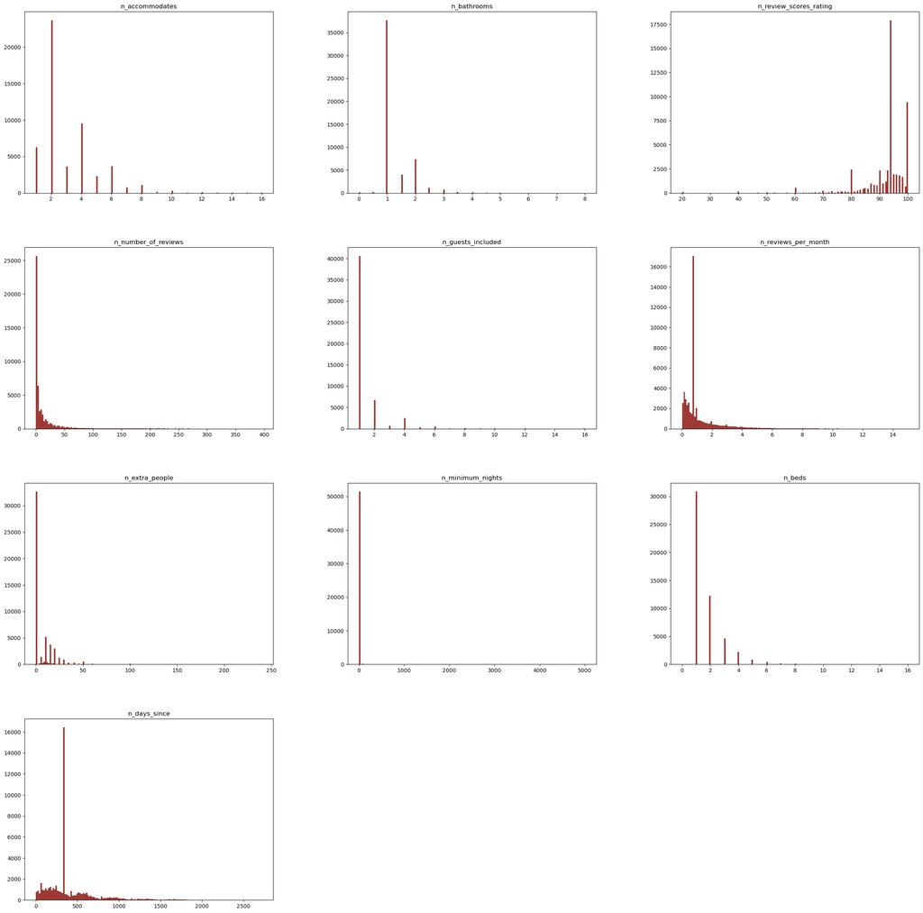

```python
graph_name('Quantitative features histogram')

df[selected_columns_n].hist(color = color_theme, figsize = (30,30), grid = False, bins = 150);
```

The same for boolean features :

*Graph 2 : Qualitative features histogram*

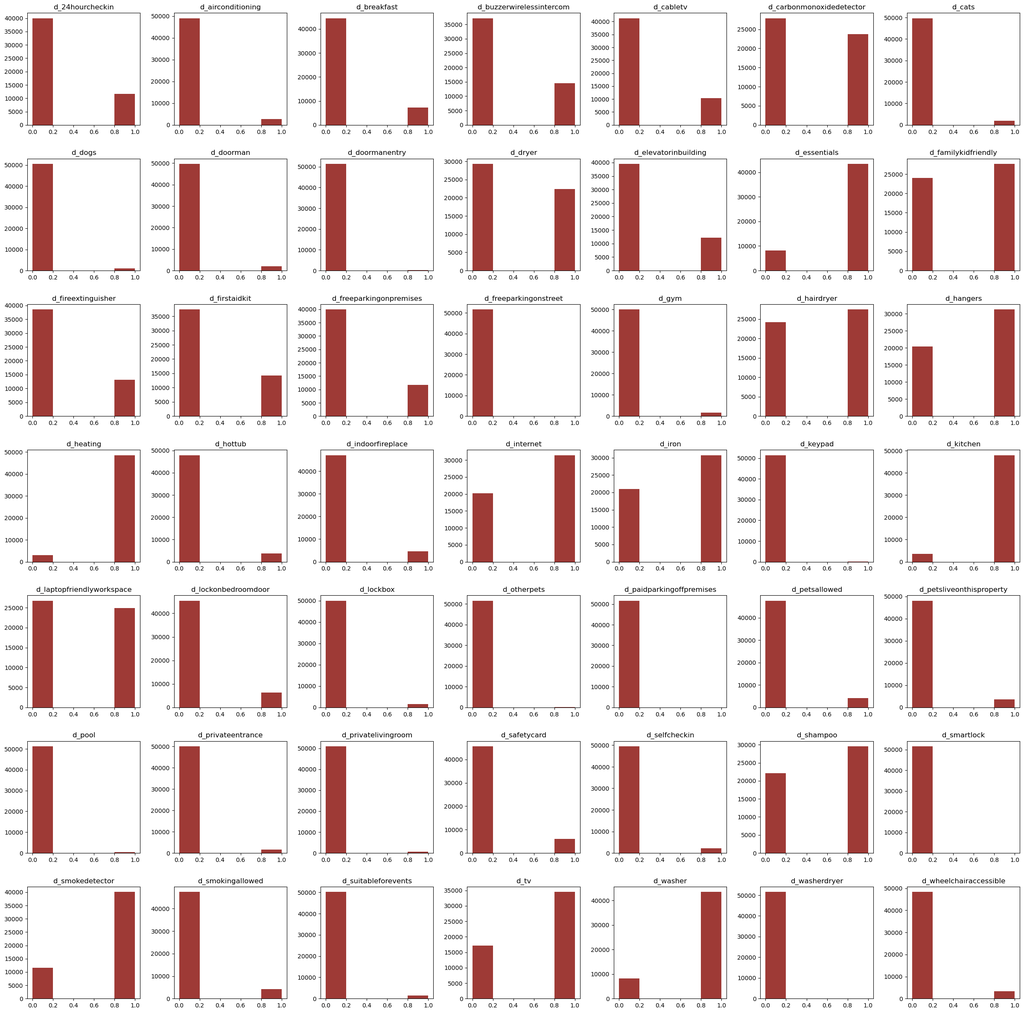

```python
graph_name("Qualitative features histogram")


df = df.replace({False : 0, True : 1})
df[selected_columns_d].hist(color = color_theme, figsize = (30,30), grid = False, bins = 5);
```

*Graph 3 : Correlation Heatmap*

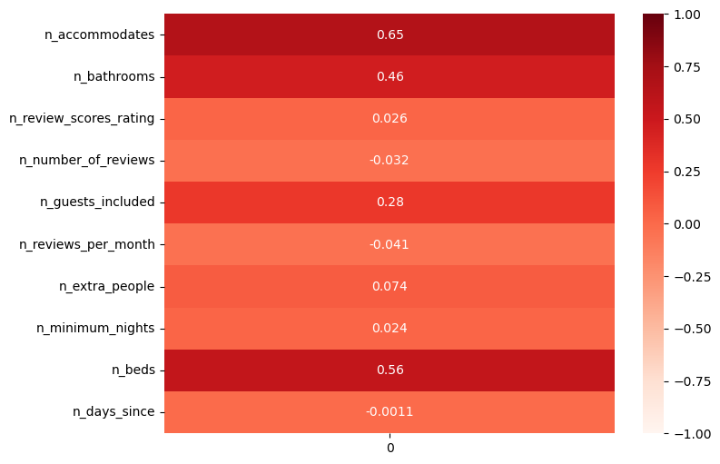

```
Correlation Columns with usd_price_day [('n_accommodates', 0.6489524427264538), ('n_beds', 0.5611478257612806), ('n_bathrooms', 0.4625743083036801), ('n_guests_included', 0.27710201039591514), ('n_extra_people', 0.07369865999319064), ('n_reviews_per_month', -0.04070877786912352), ('n_number_of_revie…
----------------------------
Columns below threshold : ['n_days_since']
```

```python
col_to_drop = []

correlation = df[selected_columns_n].corrwith(df['usd_price_day'])
# Create a list of tuples containing column name and correlation value
correlation_tuples = [(col, correlation[col]) for col in correlation.index]

# Sort the list of tuples based on the absolute correlation value
sorted_correlation_tuples = sorted(correlation_tuples, key=lambda x: abs(x[1]), reverse=True)

columns_below_threshold = [col for col in correlation.index if abs(correlation[col]) < 0.01]
col_to_drop = col_to_drop + columns_below_threshold



graph_name("Correlation Heatmap")
# Create a heatmap using seaborn
plt.figure(figsize=(8, 6))  # Adjust the figure size as needed
sns.heatmap(correlation.to_frame(), annot=True, cmap="Reds", vmin=-1, vmax=1)
plt.show()

# Print the sorted list of tuples
print('Correlation Columns with usd_price_day',sorted_correlation_tuples)
print('----------------------------')
print('Columns below threshold :', columns_below_threshold)
```

```python
import pandas as pd
from scipy.stats import chi2_contingency

# Create a DataFrame containing the selected columns
selected_df = df.loc[:, selected_columns_d + ['usd_price_day']]

# Initialize a list to store columns to drop
col_to_drop = []

# Perform chi-square test for each boolean column
for col in selected_columns_d:
    contingency_table = pd.crosstab(index=selected_df[col], columns=selected_df['usd_price_day'])
    chi2, p, _, _ = chi2_contingency(contingency_table)

    # Display the chi-square test results
    print(f"Variable: {col}")
    print(f"Chi-square statistic: {round(chi2, 3)}")
    print(f"P-value: {round(p, 3)}")

    if p >= 0.05:
        col_to_drop.append(col)
        print("The variable does not have a significant effect on 'usd_price_day'.")
    else:
        print("There is a significant association between the variable and 'usd_price_day'.")

    print("----------------------------")

# Drop non-significant columns
selected_df = selected_df.drop(columns=col_to_drop)
```

```
Variable: d_24hourcheckin
Chi-square statistic: 1968.317
P-value: 0.0
There is a significant association between the variable and 'usd_price_day'.
----------------------------
Variable: d_airconditioning
Chi-square statistic: 2191.186
P-value: 0.0
There is a significant association between the variable and 'usd_price_day'.
----------------------------
Variable: d_breakfast
Chi-square statistic: 1148.433
P-value: 0.0
There is a significant association between the variable and 'usd_price_day'.
----------------------------
Variable: d_buzzerwirelessintercom
Chi-square statistic: 2380.291
P-value: 0.0
There is a significant association between the variable and 'usd_price_day'.
----------------------------
Variable: d_cabletv
Chi-square statistic: 2401.654
P-value: 0.0
There is a significant association between the variable and 'usd_price_day'.
----------------------------
Variable: d_carbonmonoxidedetector
Chi-square statistic: 1289.19
P-value: 0.0
There is a significant association between the variable and 'usd_price_day'.
----------------------------
Variable: d_cats
Chi-square statistic: 701.807
P-value: 0.0
There is a significant association between the variable and 'usd_price_day'.
----------------------------
Variable: d_dogs
Chi-square statistic: 498.168
P-value: 0.929
The variable does not have a significant effect on 'usd_price_day'.
----------------------------
```

[output cut: 190 more lines]

```
Variable: d_washer
Chi-square statistic: 1718.911
P-value: 0.0
There is a significant association between the variable and 'usd_price_day'.
----------------------------
Variable: d_washerdryer
Chi-square statistic: 2117.655
P-value: 0.0
There is a significant association between the variable and 'usd_price_day'.
----------------------------
Variable: d_wheelchairaccessible
Chi-square statistic: 1048.086
P-value: 0.0
There is a significant association between the variable and 'usd_price_day'.
----------------------------
```

The code is designed to perform chi-squared tests for specific columns in the dataset, specifically evaluating their relationship with the ‘usd_price_day’ column. It constructs contingency tables for each selected column and ‘usd_price_day,’ computes the chi-squared statistic and p-value, and stores these results in a list. The code then iterates through the results, printing information about each variable. If a variable’s p-value is below the 5% significance level, it is considered to have a significant effect on ‘usd_price_day.’ Otherwise, the variable is added to a list named col_to_drop, indicating that it doesn’t significantly impact ‘usd_price_day’.

```python
# Create a DataFrame containing the selected columns
selected_df = df.loc[:, selected_columns_f + ['usd_price_day']]

# Perform a chi-squared test for each column
chi2_test_results = []

for col in selected_df.columns:
    if col != 'usd_price_day':
        contingency_table = pd.crosstab(selected_df[col], selected_df['usd_price_day'])
        chi2, p, _, _ = chi2_contingency(contingency_table)
        chi2_test_results.append((col, chi2, p))

# Display the chi-squared test results
for col, chi2, p in chi2_test_results:
    print(f"Variable: {col}")
    print(f"Chi-squared statistic: {round(chi2,3)}")
    print(f"P-value: {round(p,1)}")
    if p < 0.05:  # 5% significance level
        print("The variable has a significant effect on 'usd_price_day'.")
    else:
        col_to_drop += [col]
        print("The variable does not have a significant effect on 'usd_price_day'.")
    print("----------------------------")
```

```
Variable: f_property_type
Chi-squared statistic: 5014.69
P-value: 0.0
The variable has a significant effect on 'usd_price_day'.
----------------------------
Variable: f_room_type
Chi-squared statistic: 38493.07
P-value: 0.0
The variable has a significant effect on 'usd_price_day'.
----------------------------
Variable: f_cancellation_policy
Chi-squared statistic: 5156.739
P-value: 0.0
The variable has a significant effect on 'usd_price_day'.
----------------------------
Variable: f_bed_type
Chi-squared statistic: 617.338
P-value: 0.0
The variable has a significant effect on 'usd_price_day'.
----------------------------
Variable: f_neighbourhood_cleansed
Chi-squared statistic: 27694.168
P-value: 0.0
The variable has a significant effect on 'usd_price_day'.
----------------------------
```

```python
df_ = df.drop(col_to_drop, axis = 1)
selected_columns_f = [col for col in df_.columns if col.startswith('f_')]
selected_columns_n = [col for col in df_.columns if col.startswith('n_')]
selected_columns_d = [col for col in df_.columns if col.startswith('d_')]

print('List of the columns to drop :', col_to_drop)
```

```
List of the columns to drop : ['d_dogs', 'd_freeparkingonstreet', 'd_hottub', 'd_otherpets', 'd_paidparkingoffpremises', 'd_privatelivingroom']
```

We will now perform a rudimentary outlier detection to identify and mark them as missing values. Since we have missing values, we will impute them using Miss Forest to enable the algorithm to handle extreme cases for certain apartments.

We check for each variable if it is within the +- 4 sigma around the mean.

```python
# Assuming df is your DataFrame
select_columns_n = [col for col in df.columns if col.startswith('n')]
select_columns_d = [col for col in df.columns if col.startswith('d')]
select_columns_f = [col for col in df.columns if col.startswith('f')]

outliers_df = pd.DataFrame(columns=['row_number', 'column', 'value'])

for column in select_columns_n:
    col_data = df[column]
    mean_val = np.mean(col_data)
    sd_val = np.std(col_data)
    lower_limit = mean_val - 4 * sd_val
    upper_limit = mean_val + 4 * sd_val
    outliers_mask = (col_data < lower_limit) | (col_data > upper_limit)

    outliers_df = pd.concat([outliers_df,
                            pd.DataFrame({'row_number': np.where(outliers_mask)[0],
                                          'column': [column] * np.sum(outliers_mask),
                                          'value': col_data[outliers_mask].tolist()})],
                            ignore_index=True)

print(outliers_df)

# Create a new DataFrame with outliers replaced by NaN
df_with_na = df.copy()
for index, row in outliers_df.iterrows():
    df_with_na.at[row['row_number'], row['column']] = np.nan

# Print the number of rows with more than one outlier value
print(f"Number of rows with more than one outlier value: {len(set(outliers_df['row_number']))}")
```

```
     row_number          column value
0            45  n_accommodates    13
1            53  n_accommodates    11
2           263  n_accommodates    11
3           630  n_accommodates    16
4           751  n_accommodates    12
...         ...             ...   ...
3959      51485    n_days_since  1850
3960      51508    n_days_since  1805
3961      51520    n_days_since  1838
3962      51543    n_days_since  1824
3963      51588    n_days_since  2021

[3964 rows x 3 columns]
Number of rows with more than one outlier value: 3283
```

We found that there are 3,964 outliers out of 3,283 Airbnbs, we put those value in NA into a new data frame called `df_with_na`. Let’s check the repartition of outlier on each columns.

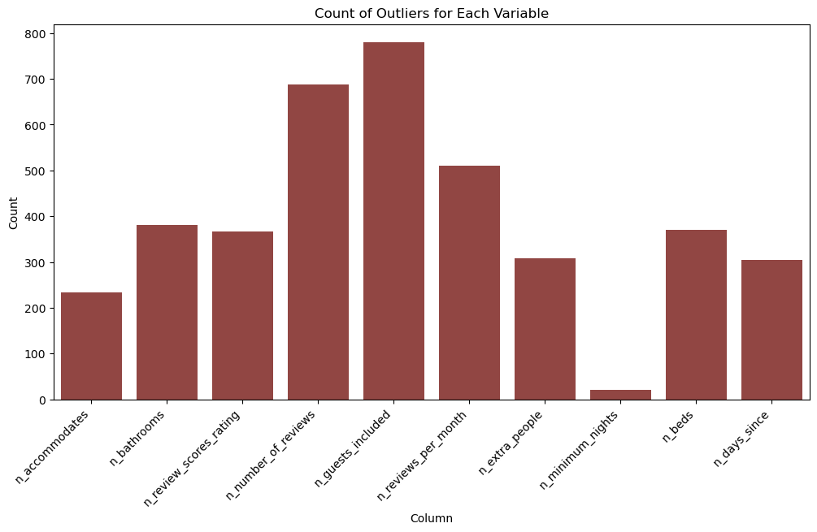

```python
plt.figure(figsize=(12, 6))
ax = sns.countplot(data=outliers_df, x='column', color=theme_color)

# Set labels and title
ax.set(xlabel='Column', ylabel='Count')
plt.title("Count of Outliers for Each Variable")

# Rotate x-axis labels for better visibility
plt.xticks(rotation=45, ha='right')

# Show the plot
plt.show()
```

Let’s now impute them with the miss forest algorithm :

```python
selected_columns_f = [col for col in df_with_na.columns if col.startswith('f_')]
selected_columns_n = [col for col in df_with_na.columns if col.startswith('n_')]
selected_columns_d = [col for col in df_with_na.columns if col.startswith('d_')]

# Function to create a DataFrame with data types and NA info
def create_info_df(columns, df):
    data_types = df[columns].dtypes
    has_na = df[columns].isna().any()
    info_df = pd.DataFrame({'Columns': columns, 'Data Types': data_types, 'Has NA': has_na})
    return info_df

# Create DataFrames for each group
info_df_f = create_info_df(selected_columns_f, df_with_na).reset_index(drop = True)
info_df_n = create_info_df(selected_columns_n, df_with_na).reset_index(drop = True)
info_df_d = create_info_df(selected_columns_d, df_with_na).reset_index(drop = True)

info_df_n[info_df_n['Has NA'] == True]
```

|  | Columns | Data Types | Has NA |
| --- | --- | --- | --- |
| 0 | n_accommodates | float64 | True |
| 1 | n_bathrooms | float64 | True |
| 2 | n_review_scores_rating | float64 | True |
| 3 | n_number_of_reviews | float64 | True |
| 4 | n_guests_included | float64 | True |
| 5 | n_reviews_per_month | float64 | True |
| 6 | n_extra_people | float64 | True |
| 7 | n_minimum_nights | float64 | True |
| 8 | n_beds | float64 | True |
| 9 | n_days_since | float64 | True |

```python
from missforest.missforest import MissForest
from sklearn.ensemble import RandomForestClassifier, RandomForestRegressor
from sklearn.preprocessing import OneHotEncoder

# Assuming df_with_na is your DataFrame
select_columns_n = [col for col in df_with_na.columns if col.startswith('n')]
select_columns_d = [col for col in df_with_na.columns if col.startswith('d')]
select_columns_f = [col for col in df_with_na.columns if col.startswith('f')]


selected_columns = select_columns_n
# Extract the selected columns from the DataFrame
df_selected = df_with_na[select_columns_n]

# Create classifiers for numeric and categorical imputation
clf_numeric = RandomForestRegressor(n_jobs=-1)
clf_categorical = RandomForestClassifier(n_jobs=-1)

# Initialize MissForest imputer with classifiers
mf = MissForest(clf_numeric)

# Fit and transform only on the selected columns
df_imputed_selected = mf.fit_transform(df_selected)

# Replace the missing values in the original DataFrame with the imputed values
df_with_na[selected_columns] = df_imputed_selected
```

[output not shown]

[output cut: 305 more lines]

[output not shown]

```python
selected_columns_f = [col for col in df_with_na.columns if col.startswith('f_')]
selected_columns_n = [col for col in df_with_na.columns if col.startswith('n_')]
selected_columns_d = [col for col in df_with_na.columns if col.startswith('d_')]

# Function to create a DataFrame with data types and NA info
def create_info_df(columns, df):
    data_types = df[columns].dtypes
    has_na = df[columns].isna().any()
    info_df = pd.DataFrame({'Columns': columns, 'Data Types': data_types, 'Has NA': has_na})
    return info_df

# Create DataFrames for each group
info_df_f = create_info_df(selected_columns_f, df_with_na).reset_index(drop = True)
info_df_n = create_info_df(selected_columns_n, df_with_na).reset_index(drop = True)
info_df_d = create_info_df(selected_columns_d, df_with_na).reset_index(drop = True)

info_df_n[info_df_n['Has NA'] == True]
```

|  | Columns | Data Types | Has NA |
| --- | --- | --- | --- |

We no longer have missing values. So, let’s observe the distributions of the quantitatives variables before and after the imputation of our variables.

**Before Impution :**

*Graph 4 : Before Impution*

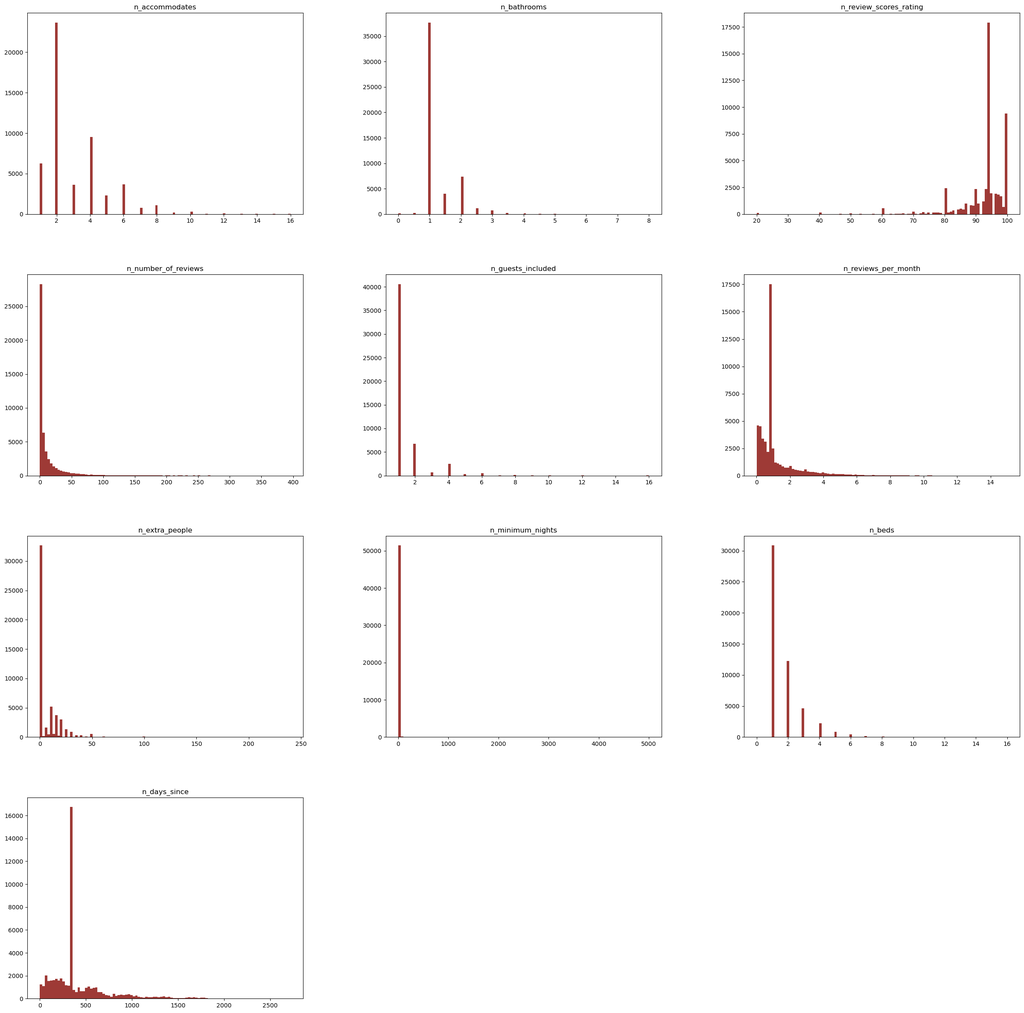

```python
graph_name("Before Impution")

df[selected_columns_n].hist(color = color_theme, figsize = (30,30), grid = False, bins = 100);
```

**After Impution :**

*Graph 5 : After Impution*

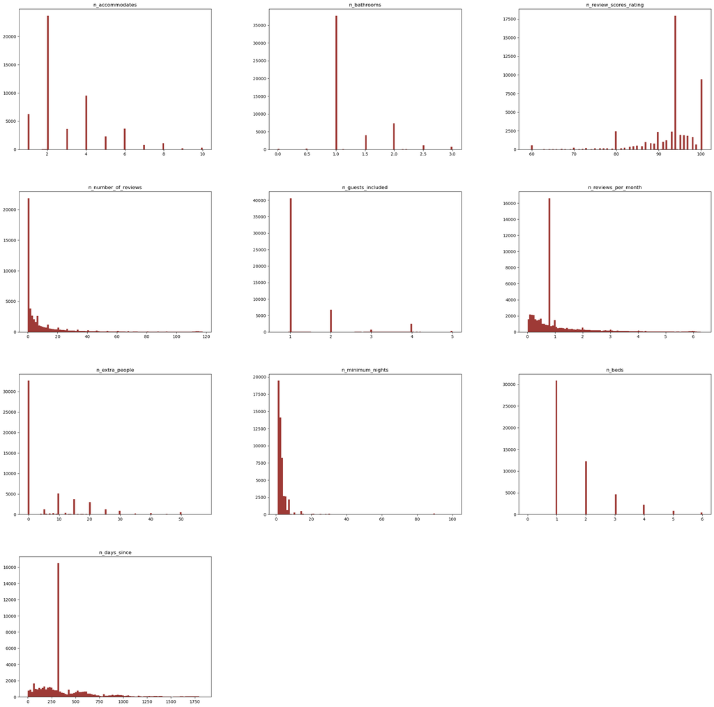

```python
graph_name("After Impution")

df_with_na[selected_columns_n].hist(color = color_theme, figsize = (30,30), grid = False, bins = 100);
```

```python
df_without_na = df.copy()
df = df_with_na
```

#### 1.1.1) Data Visualisation :

*Graph 6 : Average price per neighborhood*

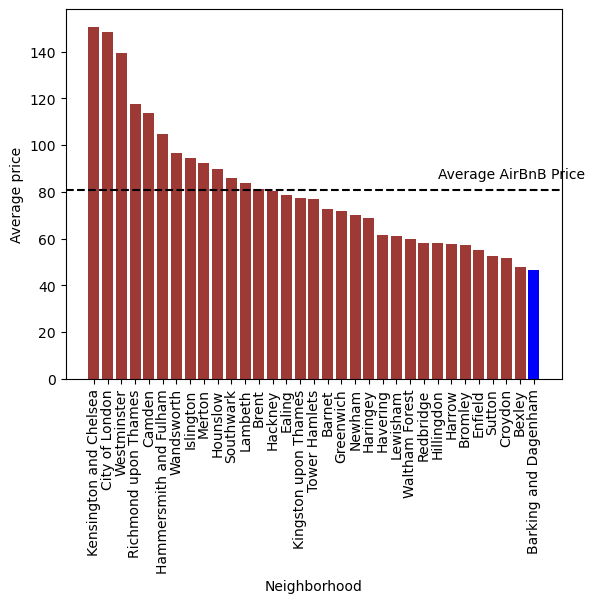

```python
import pandas as pd
import matplotlib.pyplot as plt
import numpy as np

# Assuming df is your DataFrame
dt_moy_quart = df.groupby('f_neighbourhood_cleansed')['usd_price_day'].mean().reset_index()

# Sorting by mean in descending order
dt_moy_quart = dt_moy_quart.sort_values(by='usd_price_day', ascending=False)

# Bar plot
plt.bar(dt_moy_quart['f_neighbourhood_cleansed'], dt_moy_quart['usd_price_day'],
        color=[color_theme] * (len(dt_moy_quart) - 1) + ['blue'])
graph_name("Average price per neighborhood")
plt.xlabel("Neighborhood")
plt.ylabel("Average price")
plt.xticks(rotation=90)
plt.axhline(y=np.mean(dt_moy_quart['usd_price_day']), color="black", linestyle='--', label='Average AirBnB Price')
plt.text(x=25, y=np.mean(dt_moy_quart['usd_price_day']) + 5, s="Average AirBnB Price", color="black")
plt.show()
```

*Graph 7 : Distribution of USD Price Day in Kensington and Chelsea and Barking and Dagenham*

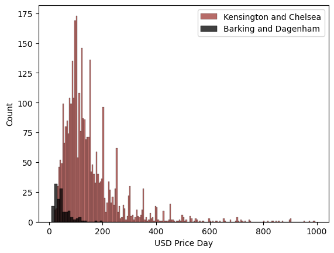

```python
ax1 = sns.histplot(data=df[df['f_neighbourhood_cleansed'] == "Kensington and Chelsea"], x='usd_price_day', stat='count',
                  color = theme_color,
                 binwidth = 5, label = "Kensington and Chelsea")
ax2 = sns.histplot(data=df[df['f_neighbourhood_cleansed'] == "Barking and Dagenham"], x='usd_price_day', stat='count',
                  color = "black",
                 binwidth = 10, label = "Barking and Dagenham")

graph_name("Distribution of USD Price Day in Kensington and Chelsea and Barking and Dagenham")





# Set labels and title
ax1.set(xlabel='USD Price Day', ylabel='Count')
plt.legend()
plt.show();
```

*Graph 8 : Distribution of USD Price Day*

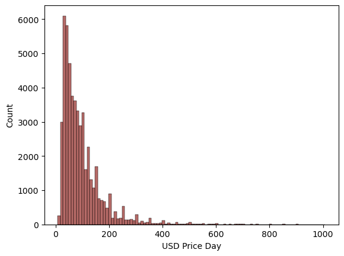

```
Skewness = 3.1673039705506523
```

```python
ax = sns.histplot(data=df, x='usd_price_day', stat='count',
                  color = theme_color,
                 binwidth = 10)
graph_name("Distribution of USD Price Day")


# Set labels and title
ax.set(xlabel='USD Price Day', ylabel='Count')
# Show the plot
plt.show();

print('Skewness =', stats.skew(df['usd_price_day']))
```

It seems that the distribtuion of the rental price didn’t follow a gaussian distribution. We can see that we have a positive skewness.  
A positive skewness in the rental price distribution indicates that the majority of rental properties in the area are relatively affordable, with only a few high-end rentals contributing to the right-skewed shape of the distribution.

Let’s create the different data set that we will use for the rest :

```python
def categorical_to_integer(df, column_name):
    unique_categories = df[column_name].unique()
    category_to_int = {category: i for i, category in enumerate(unique_categories)}
    df[column_name] = df[column_name].map(category_to_int)
    return df


def dummies_col_to_drop(df):
    global selected_columns_d, selected_columns_f, selected_columns_n
    df_new = df.copy()
    selected_columns_f = [col for col in df_new.columns if col.startswith('f_')]
    df_new = df_new.drop(col_to_drop, axis = 1)
    df_new = pd.get_dummies(df_new, columns=selected_columns_f)
    selected_columns_f = [col for col in df_new.columns if col.startswith('f_')]
    selected_columns_n = [col for col in df_new.columns if col.startswith('n_')]
    selected_columns_d = [col for col in df_new.columns if col.startswith('d_')]
    return(df_new)

def dummies_not_col_to_drop(df):
    global selected_columns_d, selected_columns_f, selected_columns_n
    df_new = df.copy()
    selected_columns_f = [col for col in df_new.columns if col.startswith('f_')]
    df_new = pd.get_dummies(df_new, columns=selected_columns_f)
    selected_columns_f = [col for col in df_new.columns if col.startswith('f_')]
    selected_columns_n = [col for col in df_new.columns if col.startswith('n_')]
    selected_columns_d = [col for col in df_new.columns if col.startswith('d_')]
    return(df_new)

def integer_col_to_drop(df):
    global selected_columns_d, selected_columns_f, selected_columns_n
    df_new = df.copy()
    selected_columns_f = [col for col in df_new.columns if col.startswith('f_')]
    df_new = df_new.drop(col_to_drop, axis = 1)
    for col in selected_columns_f:
        df_new = categorical_to_integer(df_new,col)
    selected_columns_f = [col for col in df_new.columns if col.startswith('f_')]
    selected_columns_n = [col for col in df_new.columns if col.startswith('n_')]
    selected_columns_d = [col for col in df_new.columns if col.startswith('d_')]
    return(df_new)

def integer_not_col_to_drop(df):
    global selected_columns_d, selected_columns_f, selected_columns_n
    df_new = df.copy()
    selected_columns_f = [col for col in df_new.columns if col.startswith('f_')]
    for col in selected_columns_f:
        df_new = categorical_to_integer(df_new,col)
    selected_columns_f = [col for col in df_new.columns if col.startswith('f_')]
    selected_columns_n = [col for col in df_new.columns if col.startswith('n_')]
    selected_columns_d = [col for col in df_new.columns if col.startswith('d_')]
    return(df_new)

def scale_data(df_new,col_to_scale):
    scaler = StandardScaler()

    # Find the names of the columns to scale
    columns_to_scale = [col for col in col_to_scale if col in df_new.columns]

    # Apply Z-score scaling to the specified columns
    df_new[columns_to_scale] = scaler.fit_transform(df_new[columns_to_scale])
    return(df_new)
```

### 1.2) Model Prediction :

In the preceding section, we generated three potential data sets for our analysis. Now, in this part, we will employ various models and evaluate their performance. Before proceeding, we will partition our dataset into training, testing, and evaluation sets with respective proportions of 70%, 15%, and 15%.

Our approach for each algorithm will be as follows:

1. Initially, we will identify the data set that performs the best with a base model.
2. Next, we will fine-tune the parameters and select the optimal configuration.
3. Finally, we will assess the performance of the best-tuned model on the evaluation set.

Ultimately, we will compare the performance of each algorithm.

#### a) **Linear Regression :**

We can’t do a linear regression with a data like that, we need to change into integer our categorial features or into dummies features. Note that because we do a linear regression **we can drop the column** that we found in the data processing part. Instead of changing them into integer, we will put them into dummies variable.

#### Data set selection :

**Qualitative variables into dummies :**

We will try here the data set when we drop the column selected before, and without dropping them

```python
df_lr = dummies_col_to_drop(df)
print('Dimension :', df_lr.shape)

X = df_lr.drop(['usd_price_day'], axis = 1)
y = df_lr['usd_price_day']
X_train, X_temp, y_train, y_temp = train_test_split(X, y, test_size = 0.3, random_state = seed)
X_evaluate, X_test, y_evaluate, y_test = train_test_split(X_temp, y_temp, test_size = 0.5, random_state = seed)

# fit a linear model
model_lr = LinearRegression()
model_lr.fit(X_train,y_train)
y_pred = model_lr.predict(X_test)

# MSE and RMSE :
mse_lr  = mean_squared_error(y_test,y_pred)
rmse_lr = np.sqrt(mse_lr)

print('MSE Linear Regression =', mse_lr)
print('--------------------------------')
print('RMSE Linear Regression =', rmse_lr)
```

```
Dimension : (51646, 97)
MSE Linear Regression = 2477.708431650026
--------------------------------
RMSE Linear Regression = 49.776585174658436
```

```python
df_lr = dummies_not_col_to_drop(df)

X = df_lr.drop(['usd_price_day'], axis = 1)
y = df_lr['usd_price_day']
X_train, X_temp, y_train, y_temp = train_test_split(X, y, test_size = 0.3, random_state = seed)
X_evaluate, X_test, y_evaluate, y_test = train_test_split(X_temp, y_temp, test_size = 0.5, random_state = seed)

print('Dimension of df :', df.shape)
print('Dimension of df_lr :', df_lr.shape)

print('--------------------------------')

# fit a linear model
model_lr = LinearRegression()
model_lr.fit(X_train,y_train)
y_pred = model_lr.predict(X_test)

# MSE and RMSE :
mse_lr2  = mean_squared_error(y_test,y_pred)
rmse_lr2 = np.sqrt(mse_lr2)

print('MSE Linear Regression (without droping columns) =', mse_lr2)
print('--------------------------------')
print('RMSE Linear Regression (without droping columns) =', rmse_lr2)
```

```
Dimension of df : (51646, 65)
Dimension of df_lr : (51646, 103)
--------------------------------
MSE Linear Regression (without droping columns) = 2476.6326533095526
--------------------------------
RMSE Linear Regression (without droping columns) = 49.76577793333038
```

**Qualitative variables into quantitative variables:**

Let’s try to just put our qualitative parameters into quantitative one to see if it perform better than the stuff we did previously

```python
df_lr = integer_col_to_drop(df)

X = df_lr.drop(['usd_price_day'], axis = 1)
y = df_lr['usd_price_day']
X_train, X_temp, y_train, y_temp = train_test_split(X, y, test_size = 0.3, random_state = seed)
X_evaluate, X_test, y_evaluate, y_test = train_test_split(X_temp, y_temp, test_size = 0.5, random_state = seed)


# fit a linear model
model_lr = LinearRegression()
model_lr.fit(X_train,y_train)
y_pred = model_lr.predict(X_test)

# MSE and RMSE :
mse_lr  = mean_squared_error(y_test,y_pred)
rmse_lr = np.sqrt(mse_lr)

print('MSE Linear Regression =', mse_lr)
print('--------------------------------')
print('RMSE Linear Regression =', rmse_lr)
```

```
MSE Linear Regression = 2753.5049732928182
--------------------------------
RMSE Linear Regression = 52.47385037609512
```

```python
df_lr = integer_not_col_to_drop(df)

X = df_lr.drop(['usd_price_day'], axis = 1)
y = df_lr['usd_price_day']
X_train, X_temp, y_train, y_temp = train_test_split(X, y, test_size = 0.3, random_state = seed)
X_evaluate, X_test, y_evaluate, y_test = train_test_split(X_temp, y_temp, test_size = 0.5, random_state = seed)


# fit a linear model
model_lr = LinearRegression()
model_lr.fit(X_train,y_train)
y_pred = model_lr.predict(X_test)

# MSE and RMSE :
mse_lr  = mean_squared_error(y_test,y_pred)
rmse_lr = np.sqrt(mse_lr)

print('MSE Linear Regression (without droping columns) =', mse_lr)
print('--------------------------------')
print('RMSE Linear Regression (without droping columns) =', rmse_lr)
```

```
MSE Linear Regression (without droping columns) = 2751.8581296151046
--------------------------------
RMSE Linear Regression (without droping columns) = 52.45815598755931
```

We can see that, putting the qualitative variables into dummies perform better.

**Scale Data**:

It appears that transforming our categorical values into dummy variables yields better results. Now, let’s assess how our algorithms perform when we scale the data.

```python
df_lr = dummies_col_to_drop(df)
df_lr = scale_data(df_lr,selected_columns_n)

X = df_lr.drop(['usd_price_day'], axis = 1)
y = df_lr['usd_price_day']
X_train, X_temp, y_train, y_temp = train_test_split(X, y, test_size = 0.3, random_state = seed)
X_evaluate, X_test, y_evaluate, y_test = train_test_split(X_temp, y_temp, test_size = 0.5, random_state = seed)

# fit a linear model
model_lr = LinearRegression()
model_lr.fit(X_train,y_train)
y_pred = model_lr.predict(X_test)

# MSE and RMSE :
mse_lr  = mean_squared_error(y_test,y_pred)
rmse_lr = np.sqrt(mse_lr)

print('MSE Linear Regression =', mse_lr)
print('--------------------------------')
print('RMSE Linear Regression =', rmse_lr)
```

```
MSE Linear Regression = 2480.2777280973683
--------------------------------
RMSE Linear Regression = 49.802386771091285
```

```python
df_lr = dummies_not_col_to_drop(df)
df_lr = scale_data(df_lr,selected_columns_n)
print('Dimension :', df_lr.shape)

X = df_lr.drop(['usd_price_day'], axis = 1)
y = df_lr['usd_price_day']
X_train, X_temp, y_train, y_temp = train_test_split(X, y, test_size = 0.3, random_state = seed)
X_evaluate, X_test, y_evaluate, y_test = train_test_split(X_temp, y_temp, test_size = 0.5, random_state = seed)

# fit a linear model
model_lr = LinearRegression()
model_lr.fit(X_train,y_train)
y_pred = model_lr.predict(X_test)

# MSE and RMSE :
mse_lr  = mean_squared_error(y_test,y_pred)
rmse_lr = np.sqrt(mse_lr)

print('MSE Linear Regression =', mse_lr)
print('--------------------------------')
print('RMSE Linear Regression =', rmse_lr)
```

```
Dimension : (51646, 103)
MSE Linear Regression = 2477.261251961445
--------------------------------
RMSE Linear Regression = 49.77209310408238
```

Next, let’s continue by performing feature selection using a genetic algorithm.

**Features selection, Genetic Algorithm :**

```
Generation 1/15
Generation 2/15
Generation 3/15
Generation 4/15
Generation 5/15
Generation 6/15
Generation 7/15
Generation 8/15
Generation 9/15
Generation 10/15
Generation 11/15
Generation 12/15
Generation 13/15
Generation 14/15
Generation 15/15

--------------------------------
Selected Features : ['n_accommodates', 'n_bathrooms', 'n_review_scores_rating', 'n_number_of_reviews', 'n_guests_included', 'd_airconditioning', 'd_breakfast', 'd_cabletv', 'd_carbonmonoxidedetector', 'd_cats', 'd_doorman', 'd_dryer', 'd_elevatorinbuilding', 'd_essentials', 'd_fireextinguisher', 'd_…
--------------------------------
MSE Linear Regression = 2539.006592246527
--------------------------------
RMSE Linear Regression = 50.388556163542994
```

[figure not shown]

```python
if True :
    df_lr = dummies_not_col_to_drop(df)
    df_lr = scale_data(df_lr,selected_columns_n)
    X = df_lr.drop(['usd_price_day'], axis = 1)
    y = df_lr['usd_price_day']
    X_train, X_temp, y_train, y_temp = train_test_split(X, y, test_size = 0.3, random_state = seed)
    X_evaluate, X_test, y_evaluate, y_test = train_test_split(X_temp, y_temp, test_size = 0.5, random_state = seed)


    # Create a function to evaluate the fitness of an individual (subset of features)
    def evaluate(individual):
        selected_features = [feature for feature, is_selected in zip(X_train.columns, individual) if is_selected]
        X_train_selected = X_train[selected_features]
        X_test_selected = X_test[selected_features]
        model = LinearRegression()
        model.fit(X_train_selected, y_train)
        y_pred = model.predict(X_test_selected)
        mse = mean_squared_error(y_test, y_pred)
        return mse,  # Ensure it returns a tuple with a single value

    v_mse = []

    # Create a DEAP toolbox for the GA
    creator.create("FitnessMin", base.Fitness, weights=(-1.0,))
    creator.create("Individual", list, fitness=creator.FitnessMin)
    toolbox = base.Toolbox()

    # Create a function to generate a random individual (subset of features)
    toolbox.register("attr_bool", np.random.choice, [0, 1], size=len(X_train.columns))
    toolbox.register("individual", tools.initIterate, creator.Individual, toolbox.attr_bool)
    toolbox.register("population", tools.initRepeat, list, toolbox.individual)

    # Register genetic operators
    toolbox.register("mate", tools.cxTwoPoint)
    toolbox.register("mutate", tools.mutFlipBit, indpb=0.05)
    toolbox.register("select", tools.selTournament, tournsize=5)

    # Set the GA parameters
    population_size = 150
    num_generations = 15
    crossover_prob  = 0.7
    mutation_prob   = 0.01

    # Initialize the population before the main GA loop
    population = toolbox.population(n=population_size)

    # Main GA loop
    for generation in range(num_generations):
        print(f"Generation {generation + 1}/{num_generations}")

        # Evaluate the fitness of each individual in the population
        for ind in population:
            ind.fitness.values = evaluate(ind)

        # Calculate the best MSE in this generation and store it
        best_mse = min(ind.fitness.values)
        v_mse.append(best_mse)

        # Select the next generation
        offspring = algorithms.varAnd(population, toolbox, cxpb=crossover_prob, mutpb=mutation_prob)

        # Replace the current population with the offspring
        population = toolbox.select(offspring, k=len(population))

    # Get the best individual from the final population
    best_individual = tools.selBest(population, k=1)[0]
    selected_features = [feature for feature, is_selected in zip(X_train.columns, best_individual) if is_selected]

    # Perform linear regression with the selected features
    X_train_selected = X_train[selected_features]
    X_test_selected = X_test[selected_features]
    model_selected_features = LinearRegression()
    model_selected_features.fit(X_train_selected, y_train)
    y_pred_selected_features = model_selected_features.predict(X_test_selected)

    # Calculate MSE and RMSE
    mse_lr_ga = mean_squared_error(y_test, y_pred_selected_features)
    rmse_lr_ga = np.sqrt(mse_lr_ga)
    print('\n--------------------------------')
    print('Selected Features :', selected_features)
    print('--------------------------------')
    print('MSE Linear Regression =', mse_lr_ga)
    print('--------------------------------')
    print('RMSE Linear Regression =', rmse_lr_ga)

    # Create a color palette with a single color '#FF6B6B' repeated for each generation
    salmon_palette = ['#FF6B6B'] * num_generations

    # Use Seaborn to set the color palette
    sns.set_palette(salmon_palette)

    # Create the plot with a black border around the line
    plt.plot(range(1, num_generations + 1), v_mse, marker='o',
             color=theme_color, markerfacecolor='w', markersize=5, markeredgecolor='k', lw=2)
    plt.xlabel('Generation')
    plt.ylabel('MSE')
    graph_name('MSE Evolution')
    plt.grid(False)  # Turn off the grid lines
    plt.show()
```

After fine-tuning the parameters of our Genetic Algorithm (GA), we unfortunately did not observe a significant improvement in its performance. Therefore, we will now experiment regularization method.

#### Regularization :

```python
df_lr = dummies_not_col_to_drop(df)
df_lr = scale_data(df_lr,selected_columns_n)
X = df_lr.drop(['usd_price_day'], axis = 1)
y = df_lr['usd_price_day']
X_train, X_temp, y_train, y_temp = train_test_split(X, y, test_size = 0.3, random_state = seed)
X_evaluate, X_test, y_evaluate, y_test = train_test_split(X_temp, y_temp, test_size = 0.5, random_state = seed)


#To perform CV
X_ = pd.concat([X_train,X_test], axis = 0, ignore_index = True)
y_ = pd.concat([y_train,y_test],  axis = 0, ignore_index = True)

# Create and fit a Lasso model with cross-validated alpha selection and a cross validation of 5
lasso = LassoCV(alphas=[0.005,0.01, 0.1, 1.0, 10.0], cv=cv_fold)
lasso.fit(X_, y_)

# Get the selected alpha and coefficients
best_alphaL1 = lasso.alpha_
lasso_coefs = lasso.coef_

print('Optimal alpha for Lasso :', best_alphaL1)
print('--------------------------------')

# Perform feature selection
selected_features = [feature for feature, coef in zip(X_train.columns, lasso_coefs) if coef != 0]

# Now, you can use the selected_features for further analysis or modeling
X_train_selected = X_train[selected_features]
X_test_selected  = X_test[selected_features]
model_selected_features = LinearRegression()
model_selected_features.fit(X_train_selected, y_train)

y_pred_selected_features = model_selected_features.predict(X_test_selected)

# MSE and RMSE :
mse_lr  = mean_squared_error(y_test,y_pred_selected_features)
rmse_lr_lasso = np.sqrt(mse_lr)

print('MSE Linear Regression =', mse_lr)
print('--------------------------------')
print('RMSE Linear Regression =', rmse_lr_lasso)
```

```
Optimal alpha for Lasso : 0.005
--------------------------------
MSE Linear Regression = 2476.5986803359365
--------------------------------
RMSE Linear Regression = 49.76543660348954
```

```python
df_lr = dummies_not_col_to_drop(df)
df_lr = scale_data(df_lr,selected_columns_n)
X = df_lr.drop(['usd_price_day'], axis = 1)
y = df_lr['usd_price_day']
X_train, X_temp, y_train, y_temp = train_test_split(X, y, test_size = 0.3, random_state = seed)
X_evaluate, X_test, y_evaluate, y_test = train_test_split(X_temp, y_temp, test_size = 0.5, random_state = seed)

#To perform CV
X_ = pd.concat([X_train,X_test], axis = 0, ignore_index = True)
y_ = pd.concat([y_train,y_test],  axis = 0, ignore_index = True)

# Define a range of alpha values to search
alphas = [0.005,0.01, 0.1, 1.0, 10.0]  # You can adjust this range as needed

# Create a Ridge model
ridge_regressor = Ridge()

# Perform a grid search to find the best alpha with a cross validation of 5
param_grid = {'alpha': alphas}
grid_search = GridSearchCV(ridge_regressor, param_grid, cv=cv_fold, scoring='neg_mean_squared_error')
grid_search.fit(X_, y_)

# Get the best alpha from the grid search
best_alphaL2 = grid_search.best_params_['alpha']

# Create a Ridge model with the best alpha
best_ridge_regressor = Ridge(alpha=best_alphaL2)
best_ridge_regressor.fit(X_train, y_train)

# Make predictions on the test data
y_pred_ridge = best_ridge_regressor.predict(X_test)

# Evaluate the Ridge model with the best alpha
mse_lr = mean_squared_error(y_test, y_pred_ridge)

print(f"Best Alpha for Ridge: {best_alphaL2}")
print('--------------------------------')
print(f"Mean Squared Error (Ridge) = {mse_lr}")
print('--------------------------------')
print('RMSE Linear Regression (Ridge) =', np.sqrt(mse_lr))
```

```
Best Alpha for Ridge: 1.0
--------------------------------
Mean Squared Error (Ridge) = 2476.7040545824048
--------------------------------
RMSE Linear Regression (Ridge) = 49.766495301381276
```

After tunning parameters for our Genetic Algorithm (GA) and exploring Ridge and Lasso regression, we found that the best performance was achieved using Lasso regression with a regularization coefficient of 0.005. However, upon comparing the Mean Squared Error (MSE) obtained with Lasso regression to the MSE achieved with the linear regression function provided by the sklearn package, it became evident that the sklearn package’s optimization outperforms our custom GA-based approach. Despite our efforts, we were unable to surpass its performance.

We can conclude that the most effective model achieved via linear regression involves the conversion of categorical features into dummy variables, and the scaling of the data. This optimization was successfully accomplished through the utilization of Lasso Regression.

Now, let’s assess the performance of our selected algorithm on the evaluation set:

#### Evaluation :

```python
df_lr = dummies_not_col_to_drop(df)
df_lr = scale_data(df_lr,selected_columns_n)
X = df_lr.drop(['usd_price_day'], axis = 1)
y = df_lr['usd_price_day']
X_train, X_temp, y_train, y_temp = train_test_split(X, y, test_size = 0.3, random_state = seed)
X_evaluate, X_test, y_evaluate, y_test = train_test_split(X_temp, y_temp, test_size = 0.5, random_state = seed)


lasso = Lasso(alpha=best_alphaL1)
lasso.fit(X_train, y_train)

lasso_coefs = lasso.coef_

# Perform feature selection
selected_features = [feature for feature, coef in zip(X_train.columns, lasso_coefs) if coef != 0]

# Now, you can use the selected_features for further analysis or modeling
X_train_selected = X_train[selected_features]
X_evaluate_selected  = X_evaluate[selected_features]
model_selected_features = LinearRegression()
model_selected_features.fit(X_train_selected, y_train)

y_pred_selected_features = model_selected_features.predict(X_evaluate_selected)

# MSE and RMSE :
mse_lr  = mean_squared_error(y_evaluate,y_pred_selected_features)
rmse_lr = np.sqrt(mse_lr)

print('MSE Linear Regression =', mse_lr)
print('--------------------------------')
print('RMSE Linear Regression =', rmse_lr)
```

```
MSE Linear Regression = 2703.6068590764185
--------------------------------
RMSE Linear Regression = 51.99621966139864
```

#### b) **RandomForestRegressor:**

Since Random Forest makes use of non-linear interactions between variables, we won’t be dropping any columns in this case.

#### Data set selection :

**Qualitative variables into dummies :**

```python
df_rf = dummies_not_col_to_drop(df)

X = df_rf.drop(['usd_price_day'], axis = 1)
y = df_rf['usd_price_day']
X_train, X_temp, y_train, y_temp = train_test_split(X, y, test_size = 0.3, random_state = seed)
X_evaluate, X_test, y_evaluate, y_test = train_test_split(X_temp, y_temp, test_size = 0.5, random_state = seed)


# Create a Random Forest Regressor
rf_regressor = RandomForestRegressor(n_estimators=100, random_state=seed)  # You can adjust the number of trees (n_estimators) as needed

# Fit the model on the training data
rf_regressor.fit(X_train, y_train)

# Make predictions on the test data
y_pred = rf_regressor.predict(X_test)

# Evaluate the model (for regression tasks, you can use mean squared error or other appropriate metrics)
mse_rf  = mean_squared_error(y_test,y_pred)
rmse_rf = np.sqrt(mse_rf)

print('MSE Random Forest =', mse_rf)
print('--------------------------------')
print('RMSE Random Forest =', rmse_rf)
```

```
MSE Random Forest = 2108.898726683195
--------------------------------
RMSE Random Forest = 45.922747377342255
```

**Qualitative variables into quantitative variables:**

```python
df_rf = integer_not_col_to_drop(df)

X = df_rf.drop(['usd_price_day'], axis = 1)
y = df_rf['usd_price_day']

X_train, X_temp, y_train, y_temp = train_test_split(X, y, test_size = 0.3, random_state = seed)
X_evaluate, X_test, y_evaluate, y_test = train_test_split(X_temp, y_temp, test_size = 0.5, random_state = seed)

# Create a Random Forest Regressor
rf_regressor = RandomForestRegressor(n_estimators=100, random_state=seed)  # You can adjust the number of trees (n_estimators) as needed

# Fit the model on the training data
rf_regressor.fit(X_train, y_train)

# Make predictions on the test data
y_pred = rf_regressor.predict(X_test)

# Evaluate the model (for regression tasks, you can use mean squared error or other appropriate metrics)
mse_rf  = mean_squared_error(y_test,y_pred)
rmse_rf = np.sqrt(mse_rf)

print('MSE Random Forest =', mse_rf)
print('--------------------------------')
print('RMSE Random Forest =', rmse_rf)
```

```
MSE Random Forest = 2114.79631665708
--------------------------------
RMSE Random Forest = 45.98691462423936
```

**Scaling Data: (Categorical to Dummies)**

It’s important to highlight that scaling the data for algorithms like Random Forest may not have a significant impact. These algorithms do not consider the magnitude of the data, as their focus is primarily on how they partition the data into decision trees.

```python
df_rf = dummies_not_col_to_drop(df)
df_rf = scale_data(df_rf,selected_columns_n)

X = df_rf.drop(['usd_price_day'], axis = 1)
y = df_rf['usd_price_day']
X_train, X_temp, y_train, y_temp = train_test_split(X, y, test_size = 0.3, random_state = seed)
X_evaluate, X_test, y_evaluate, y_test = train_test_split(X_temp, y_temp, test_size = 0.5, random_state = seed)

# Create a Random Forest Regressor
rf_regressor = RandomForestRegressor(n_estimators=100, random_state=seed)  # You can adjust the number of trees (n_estimators) as needed

# Fit the model on the training data
rf_regressor.fit(X_train, y_train)

# Make predictions on the test data
y_pred = rf_regressor.predict(X_test)

# Evaluate the model (for regression tasks, you can use mean squared error or other appropriate metrics)
mse_rf  = mean_squared_error(y_test,y_pred)
rmse_rf = np.sqrt(mse_rf)

print('MSE Random Forest =', mse_rf)
print('--------------------------------')
print('RMSE Random Forest =', rmse_rf)
```

```
MSE Random Forest = 2111.573403821936
--------------------------------
RMSE Random Forest = 45.95185963399018
```

The performance are not better than without scalling

The dataset where our baseline Random Forest model performs best is the one where qualitative variables are converted into dummy variables, and data scaling is not applied. We will use this dataset as the basis for tuning the parameters of the Random Forest model.

#### Tunning parameters :

```python
df_rf = dummies_not_col_to_drop(df)

X = df_rf.drop(['usd_price_day'], axis = 1)
y = df_rf['usd_price_day']
X_train, X_temp, y_train, y_temp = train_test_split(X, y, test_size = 0.3, random_state = seed)
X_evaluate, X_test, y_evaluate, y_test = train_test_split(X_temp, y_temp, test_size = 0.5, random_state = seed)

# To deal with CV
X_ = pd.concat([X_train,X_test], axis = 0, ignore_index = True)
y_ = pd.concat([y_train,y_test],  axis = 0, ignore_index = True)

#Run_Code = True
```

*GridSearch :*

```python
if Run_Code:
    # Define the parameter grid to search
    param_grid = {
        'n_estimators': [150, 200,250, 300, 350],
        'max_depth': [None, 1, 2, 3],
        'min_samples_split': [2, 5],
        'min_samples_leaf': [1, 2, 3, 4],
        'max_features': ['sqrt', 'log2'],
        'random_state': [seed]
    }

    # Create a Random Forest Regressor
    rf_regressor = RandomForestRegressor()

    # Gridsearch with a cross validation of 5
    grid_search = GridSearchCV(estimator=rf_regressor,
                               param_grid=param_grid,
                               cv=cv_fold,
                               n_jobs = 8,
                               verbose = 1,
                               scoring='neg_mean_squared_error')

    start_time = time.time()

    # Perform the grid search
    grid_search.fit(X_, y_)

    # Get the best parameters
    best_params = grid_search.best_params_

    # Create a Random Forest Regressor with the best parameters
    best_rf_regressor = RandomForestRegressor(**best_params)

    # Fit the model on the training data with the best parameters
    best_rf_regressor.fit(X_train, y_train)

    # Make predictions on the test data
    y_pred = best_rf_regressor.predict(X_test)


    grid_search_time = time.time() - start_time

    # Evaluate the model with the best parameters
    mse_rf = mean_squared_error(y_test, y_pred)
    rmse_rf = np.sqrt(mse_rf)

    print('Time taken for grid search: {:.2f} seconds'.format(grid_search_time))
    print('--------------------------------')
    print('Best Parameters for Random Forest:', best_params)
    print('--------------------------------')
    print('MSE Random Forest with Best Parameters:', mse_rf)
    print('--------------------------------')
    print('RMSE Random Forest with Best Parameters:', rmse_rf)
```

```
Fitting 5 folds for each of 320 candidates, totalling 1600 fits
Time taken for grid search: 2637.31 seconds
--------------------------------
Best Parameters for Random Forest: {'max_depth': None, 'max_features': 'sqrt', 'min_samples_leaf': 1, 'min_samples_split': 2, 'n_estimators': 350, 'random_state': 42}
--------------------------------
MSE Random Forest with Best Parameters: 1959.6751837615416
--------------------------------
RMSE Random Forest with Best Parameters: 44.268218664879
```

*RandomSearch :*

```
Randomized search performed in 10167s
Best Mean Squared Error: 2212.2828
n_estimators: 200
min_samples_split: 2
min_samples_leaf: 1
max_features: sqrt
max_depth: 20
```

[figure not shown]

```python
if Run_Code:

    def tune_random_forest_hyperparameters(X_train, y_train, cv_fold=5):
        # Define the hyperparameter grid
        grid = {
            'n_estimators': [50, 100, 125 , 150, 175,  200],
            'max_features': ['sqrt', 'log2'],
            'max_depth': [1, 2, 3, 5,10,20],
            'min_samples_split': [2, 5],
            'min_samples_leaf': [1, 2, 3, 4]
        }

        # Create the Random Forest model
        model_rf = RandomForestRegressor()

        # Perform randomized search for hyperparameter tuning
        tic = time.time()
        rando_search = RandomizedSearchCV(
            estimator=model_rf,
            param_distributions=grid,
            cv=cv_fold,
            n_iter=500,
            n_jobs=8,
            scoring='neg_mean_squared_error'
        )

        rando_result = rando_search.fit(X_, y_)

        # Print the results
        printstring = f"Randomized search performed in {time.time() - tic:.0f}s\n"
        printstring += f"Best Mean Squared Error: {-rando_result.best_score_:.4f}\n"

        for k, v in rando_result.best_params_.items():
            printstring += f"{k}: {v}\n"

        print(printstring)

        # Optionally, visualize the results
        visualize_search_results(rando_search)

   # Define a color mapping function based on iteration
    def get_color(iteration):
        if iteration < 100:
            return theme_color  # Color for iteration < 100
        elif iteration < 200:
            return 'lightgray'  # Color for iteration < 200
        elif iteration < 300:
            return 'salmon'  # Color for iteration < 300
        elif iteration < 400:
            return 'red'
        else :
            return 'orange'

    def visualize_search_results(search_results):
        means = search_results.cv_results_['mean_test_score']
        params = search_results.cv_results_['params']

        # Plot the distribution of mean squared errors for different hyperparameters
        plt.figure(figsize=(10, 6))

        for i in range(len(means)):
            color = get_color(i)  # Determine the color based on iteration
            plt.scatter(i, means[i], c=color, s=10)

        graph_name('Randomized Search Results')
        plt.xlabel('Iteration')
        plt.ylabel('Mean Squared Error')
        plt.grid(True)
        plt.show()
    # Usage:
    tune_random_forest_hyperparameters(X_train, y_train, cv_fold=cv_fold)
```

```python
print(f"The one that perform better was the grid search that give a Random forest model with those parameters : \n {best_params}")
```

```
The one that perform better was the grid search that give a Random forest model with those parameters :
 {'max_depth': None, 'max_features': 'sqrt', 'min_samples_leaf': 1, 'min_samples_split': 2, 'n_estimators': 350, 'random_state': 42}
```

We will then use the Random Forest Regressor using the parameters obtained with the grid search algorith on the evaluate test set.

#### Evaluation :

```python
df_rf = dummies_not_col_to_drop(df)

X = df_rf.drop(['usd_price_day'], axis = 1)
y = df_rf['usd_price_day']
X_train, X_temp, y_train, y_temp = train_test_split(X, y, test_size = 0.3, random_state = seed)
X_evaluate, X_test, y_evaluate, y_test = train_test_split(X_temp, y_temp, test_size = 0.5, random_state = seed)


rf_model = RandomForestRegressor(**best_params)

# Fit the model to your data
rf_model.fit(X_train, y_train)

y_pred = rf_model.predict(X_evaluate)

mse_rf  = mean_squared_error(y_evaluate,y_pred)
rmse_rf = np.sqrt(mse_rf)

print('MSE Random Forest =', mse_rf)
print('--------------------------------')
print('RMSE Random Forest =', rmse_rf)
```

```
MSE Random Forest = 2159.344900731611
--------------------------------
RMSE Random Forest = 46.46875187404554
```

#### **c) Neural Network :**

We will implement a neural network using the ReLU activation function for the hidden layers and linear regression for the output layer. Since we are working with linear models in this context, we will first remove the column we identified during the data preprocessing stage and scale our data.

#### Data set selection :

**Qualitative variables into dummies :**

We will try here the data set when we drop the column selected before, and without dropping them

```python
df_nn = dummies_col_to_drop(df)
X = df_nn.drop(['usd_price_day'], axis = 1)
y = df_nn['usd_price_day']
X_train, X_temp, y_train, y_temp = train_test_split(X, y, test_size = 0.3, random_state = seed)
X_evaluate, X_test, y_evaluate, y_test = train_test_split(X_temp, y_temp, test_size = 0.5, random_state = seed)

n, d = X_train.shape

np.random.seed(seed)
tf.random.set_seed(seed)

# Define our neural network model
model = Sequential()
model.add(Dense(128, input_dim=d, activation='relu'))
model.add(Dense(64, activation='relu'))
model.add(Dense(1, activation='linear'))

# Compile the model
model.compile(loss='mean_squared_error', optimizer=Adam(learning_rate=0.001))

# Fit the model on the training data
model.fit(X_train, y_train, epochs=50, batch_size=32, validation_data=(X_test, y_test))

# Make predictions on the test data
y_pred = model.predict(X_test)

# Calculate the mean squared error
mse_nn = mean_squared_error(y_test, y_pred)
rmse_nn = np.sqrt(mse_nn)

clear_output(wait=True)
print('MSE Neural Network =', mse_nn)
print('--------------------------------')
print('RMSE Neural Network =', rmse_nn)
```

```
MSE Neural Network = 2055.0571797071725
--------------------------------
RMSE Neural Network = 45.33273849776972
```

```python
df_lr = dummies_not_col_to_drop(df)

X = df_lr.drop(['usd_price_day'], axis = 1)
y = df_lr['usd_price_day']
X_train, X_temp, y_train, y_temp = train_test_split(X, y, test_size = 0.3, random_state = seed)
X_evaluate, X_test, y_evaluate, y_test = train_test_split(X_temp, y_temp, test_size = 0.5, random_state = seed)
n, d = X_train.shape

np.random.seed(seed)
tf.random.set_seed(seed)

# Define our neural network model
model = Sequential()
model.add(Dense(128, input_dim=d, activation='relu'))
model.add(Dense(64, activation='relu'))
model.add(Dense(1, activation='linear'))

# Compile the model
model.compile(loss='mean_squared_error', optimizer=Adam(learning_rate=0.001))

# Fit the model on the training data
model.fit(X_train, y_train, epochs=50, batch_size=32, validation_data=(X_test, y_test))

# Make predictions on the test data
y_pred = model.predict(X_test)

# Calculate the mean squared error
mse_nn = mean_squared_error(y_test, y_pred)
rmse_nn = np.sqrt(mse_nn)

clear_output(wait=True)
print('MSE Neural Network (without droping columns) =', mse_nn)
print('--------------------------------')
print('RMSE Neural Network (without droping columns) =', rmse_nn)
```

```
MSE Neural Network (without droping columns) = 2047.5074967654618
--------------------------------
RMSE Neural Network (without droping columns) = 45.24939222537096
```

The model without dropping columns perform better

**Qualitative variables into quantitative variables:**

Let’s try to just put our qualitative parameters into quantitative one to see if it perform better than the stuff we did previously

```python
df_nn = integer_col_to_drop(df)
X = df_nn.drop(['usd_price_day'], axis = 1)
y = df_nn['usd_price_day']
X_train, X_temp, y_train, y_temp = train_test_split(X, y, test_size = 0.3, random_state = seed)
X_evaluate, X_test, y_evaluate, y_test = train_test_split(X_temp, y_temp, test_size = 0.5, random_state = seed)

n, d = X_train.shape

np.random.seed(seed)
tf.random.set_seed(seed)

# Define our neural network model

model = Sequential()
model.add(Dense(128, input_dim=d, activation='relu'))
model.add(Dense(64, activation='relu'))
model.add(Dense(1, activation='linear'))

# Compile the model
model.compile(loss='mean_squared_error', optimizer=Adam(learning_rate=0.001))

# Fit the model on the training data
model.fit(X_train, y_train, epochs=50, batch_size=32, validation_data=(X_test, y_test))

# Make predictions on the test data
y_pred = model.predict(X_test)

clear_output(wait=True)
# Calculate the mean squared error
mse_nn = mean_squared_error(y_test, y_pred)
rmse_nn = np.sqrt(mse_nn)

print('MSE Neural Network =', mse_nn)
print('--------------------------------')
print('RMSE Neural Network =', rmse_nn)
```

```
MSE Neural Network = 2255.9831066786323
--------------------------------
RMSE Neural Network = 47.49719051353072
```

```python
df_nn = integer_not_col_to_drop(df)
X = df_nn.drop(['usd_price_day'], axis = 1)
y = df_nn['usd_price_day']
X_train, X_temp, y_train, y_temp = train_test_split(X, y, test_size = 0.3, random_state = seed)
X_evaluate, X_test, y_evaluate, y_test = train_test_split(X_temp, y_temp, test_size = 0.5, random_state = seed)

n, d = X_train.shape

np.random.seed(seed)
tf.random.set_seed(seed)

# Define our neural network model

model = Sequential()
model.add(Dense(128, input_dim=d, activation='relu'))
model.add(Dense(64, activation='relu'))
model.add(Dense(1, activation='linear'))

# Compile the model
model.compile(loss='mean_squared_error', optimizer=Adam(learning_rate=0.001))

# Fit the model on the training data
model.fit(X_train, y_train, epochs=50, batch_size=32, validation_data=(X_test, y_test))

# Make predictions on the test data
y_pred = model.predict(X_test)

clear_output(wait=True)
# Calculate the mean squared error
mse_nn = mean_squared_error(y_test, y_pred)
rmse_nn = np.sqrt(mse_nn)

print('MSE Neural Network (without dropping columns)  =', mse_nn)
print('--------------------------------')
print('RMSE Neural Network (without dropping columns) =', rmse_nn)
```

```
MSE Neural Network (without dropping columns)  = 2296.5996017895936
--------------------------------
RMSE Neural Network (without dropping columns) = 47.92285051819845
```

**Scale Data**:

It appears that transforming our categorical values into dummy variables yields better results. Now, let’s assess how our algorithms perform when we scale the data.

```python
df_nn = dummies_not_col_to_drop(df)
df_nn = scale_data(df_nn, selected_columns_n)
X = df_nn.drop(['usd_price_day'], axis = 1)
y = df_nn['usd_price_day']
X_train, X_temp, y_train, y_temp = train_test_split(X, y, test_size = 0.3, random_state = seed)
X_evaluate, X_test, y_evaluate, y_test = train_test_split(X_temp, y_temp, test_size = 0.5, random_state = seed)

n, d = X_train.shape

np.random.seed(seed)
tf.random.set_seed(seed)

# Define our neural network model

model = Sequential()
model.add(Dense(128, input_dim=d, activation='relu'))
model.add(Dense(64, activation='relu'))
model.add(Dense(1, activation='linear'))

# Compile the model
model.compile(loss='mean_squared_error', optimizer=Adam(learning_rate=0.001))

# Fit the model on the training data
model.fit(X_train, y_train, epochs=50, batch_size=32, validation_data=(X_test, y_test))

# Make predictions on the test data
y_pred = model.predict(X_test)

clear_output(wait=True)
# Calculate the mean squared error
mse_nn = mean_squared_error(y_test, y_pred)
rmse_nn = np.sqrt(mse_nn)

print('MSE Neural Network =', mse_nn)
print('--------------------------------')
print('RMSE Neural Network =', rmse_nn)
```

```
MSE Neural Network = 2122.1226936304456
--------------------------------
RMSE Neural Network = 46.066502945529145
```

The data transformation that gives us the best performance on our base model is the one with dummy variables, without dropping any columns, and with unscaled data.

#### Regularization :

Let’s now try to perform L1 and L2 regularization (lasso and ridge) on our input and hidden layers and see how they perform.

```python
df_lr = dummies_not_col_to_drop(df)

X = df_lr.drop(['usd_price_day'], axis = 1)
y = df_lr['usd_price_day']
X = scale_data(X,selected_columns_n)
X_train, X_temp, y_train, y_temp = train_test_split(X, y, test_size = 0.3, random_state = seed)
X_evaluate, X_test, y_evaluate, y_test = train_test_split(X_temp, y_temp, test_size = 0.5, random_state = seed)
n, d = X_train.shape

# Set a random seed
np.random.seed(seed)
tf.random.set_seed(seed)

alpha_to_try = [0, 0.001, 0.01, 0.1, 1]

# Define our neural network model
best_mse = []
best_alpha = None  # Initialize the variable to store the best alpha
best_rmse = None   # Initialize the variable to store the best RMSE

for alpha in alpha_to_try:
    model = Sequential()
    model.add(Dense(128, input_dim=d, activation='relu', kernel_regularizer=l1(alpha)))
    model.add(Dense(64, activation='relu', kernel_regularizer=l1(alpha)))
    model.add(Dense(1, activation='linear'))

    # Compile the model
    model.compile(loss='mean_squared_error', optimizer=Adam(learning_rate=0.001))

    # Fit the model on the training data
    model.fit(X_train, y_train, epochs=50, batch_size=32, validation_data=(X_test, y_test))

    # Make predictions on the test data
    y_pred = model.predict(X_test)

    # Calculate the mean squared error and store it
    mse_nn = mean_squared_error(y_test, y_pred)
    best_mse.append(mse_nn)

    # Check if this is the best result so far
    if best_alpha is None or mse_nn < min(best_mse):
        best_alpha = alpha
        best_rmse = np.sqrt(mse_nn)

    # Clear the output because it took too much place
    clear_output(wait=True)
    print('Trying alpha =', alpha)

clear_output(wait=True)
best_alphaL1 = best_alpha
mse_nn_L1 = np.min(best_mse)
rmse_nn = np.sqrt(mse_nn)

print('L1 :')
print('--------------------------------')
print('MSE Neural Network =', mse_nn_L1)
print('Best Alpha =', best_alphaL1)
print('Best RMSE =', best_rmse)
print('--------------------------------')
```

```
L1 :
--------------------------------
MSE Neural Network = 1961.1414322403084
Best Alpha = 0
Best RMSE = 47.191754396082494
--------------------------------
```

```python
df_lr = dummies_not_col_to_drop(df)

X = df_lr.drop(['usd_price_day'], axis = 1)
y = df_lr['usd_price_day']
X = scale_data(X, selected_columns_n)
X_train, X_temp, y_train, y_temp = train_test_split(X, y, test_size = 0.3, random_state = seed)
X_evaluate, X_test, y_evaluate, y_test = train_test_split(X_temp, y_temp, test_size = 0.5, random_state = seed)
n, d = X_train.shape

# Set a random seed
np.random.seed(seed)
tf.random.set_seed(seed)

alpha_to_try = [0, 0.001, 0.01, 0.1, 1]

# Define your neural network model
best_mse = []
best_alpha = None  # Initialize the variable to store the best alpha
best_rmse = None   # Initialize the variable to store the best RMSE

for alpha in alpha_to_try:
    model = Sequential()
    model.add(Dense(128, input_dim=d, activation='relu', kernel_regularizer=l2(alpha)))
    model.add(Dense(64, activation='relu', kernel_regularizer=l2(alpha)))
    model.add(Dense(1, activation='linear'))

    # Compile the model
    model.compile(loss='mean_squared_error', optimizer=Adam(learning_rate=0.001))

    # Fit the model on the training data
    model.fit(X_train, y_train, epochs=50, batch_size=32, validation_data=(X_test, y_test))

    # Make predictions on the test data
    y_pred = model.predict(X_test)

    # Calculate the mean squared error and store it
    mse_nn = mean_squared_error(y_test, y_pred)
    best_mse.append(mse_nn)

    # Check if this is the best result so far
    if best_alpha is None or mse_nn < min(best_mse):
        best_alpha = alpha
        best_rmse = np.sqrt(mse_nn)

    # Clear the output because it took too much place
    clear_output(wait=True)
    print('Trying alpha =', alpha)

clear_output(wait=True)
best_alphaL2 = best_alpha
mse_nn_L2 = np.min(best_mse)
rmse_nn = np.sqrt(mse_nn)

print('L2 :')
print('--------------------------------')
print('MSE Neural Network =', mse_nn_L2)
print('Best Alpha =', best_alphaL2)
print('Best RMSE =', best_rmse)
print('--------------------------------')
```

```
L2 :
--------------------------------
MSE Neural Network = 1906.966932673867
Best Alpha = 0
Best RMSE = 45.96420824352791
--------------------------------
```

#### Tuning Parameters of Our Neural Network:

In the initial phase of parameter tuning, we selected the model that performed the best without any regularization. Next, we fine-tuned the regularization term before making adjustments to the parameters of our neural network. We also explored the application of both L1 and L2 regularization techniques.

```python
if mse_nn_L1 > mse_nn_L2 :
    best_alpha = best_alphaL2
else:
    best_alpha = best_alphaL1


# Function to build the Neural Networks
def build_model(hp):
    model = Sequential()
    model.add(Dense(units=hp.Int('units_1', min_value=64, max_value=256, step=1),
                input_dim=d, activation=hp.Choice('activation_1', values=['relu', 'tanh']),kernel_regularizer=l2(best_alpha)))
    model.add(Dense(units=hp.Int('units_2', min_value=32, max_value=128, step=1),
                activation=hp.Choice('activation_2', values=['relu', 'tanh']),kernel_regularizer=l2(best_alpha)))
    model.add(Dense(1, activation='linear'))

    optimizer = Adam(learning_rate=hp.Choice('learning_rate', values=[0.001, 0.01, 0.1, 1.0]))
    model.compile(loss='mean_squared_error', optimizer=optimizer)

    return model


start_time = time.time()

# Initialize the RandomSearch tuner
tuner = RandomSearch(
    build_model,
    objective='val_loss',
    max_trials=10,  # Adjust the number of trials
    directory='my_tuner_directory'  # Create a directory to store tuner results
)

# Perform hyperparameter search
tuner.search(X_train, y_train, epochs=50, validation_data=(X_test, y_test))

# Get the best hyperparameters
best_hps = tuner.get_best_hyperparameters(num_trials=1)[0]

# Build and compile the best model
best_model = build_model(best_hps)

# Fit the best model on the training data
best_model.fit(X_train, y_train, epochs=50, validation_data=(X_test, y_test))

# Make predictions on the test data
y_pred = best_model.predict(X_test)

# Calculate the mean squared error
mse_nn = mean_squared_error(y_test, y_pred)
rmse_nn = np.sqrt(mse_nn)

end_time = time.time()
execution_time = end_time - start_time

#clear the output because it took too much place
clear_output(wait=True)
print('MSE Neural Network =', mse_nn)
print('--------------------------------')
print('RMSE Neural Network =', rmse_nn)
print('--------------------------------')
print('Execution Time:', execution_time, 'seconds')

# Output the chosen hyperparameters
print('Chosen Hyperparameters:')
print('units_1:', best_hps.get('units_1'))
print('activation_1:', best_hps.get('activation_1'))
print('units_2:', best_hps.get('units_2'))
print('activation_2:', best_hps.get('activation_2'))
print('learning_rate:', best_hps.get('learning_rate'))

# Delete the 'my_turner_directory' where we store the information from our hyper parameters
if True:
    import shutil

    # Path to the tuner directory
    tuner_directory = 'my_tuner_directory'

    # Remove the tuner directory and its contents
    shutil.rmtree(tuner_directory)
    print('my_tuner_directory deleted')
```

```
MSE Neural Network = 2054.0461389188135
--------------------------------
RMSE Neural Network = 45.32158579439618
--------------------------------
Execution Time: 290.14751076698303 seconds
Chosen Hyperparameters:
units_1: 96
activation_1: relu
units_2: 62
activation_2: relu
learning_rate: 0.001
my_tuner_directory deleted
```

#### Evaluation :

It appears that our default model outperforms the one achieved through parameter tuning.

```python
if mse_nn_L1 > mse_nn_L2 :
    best_alpha = best_alphaL2
else:
    best_alpha = best_alphaL1

df_lr = dummies_not_col_to_drop(df)

X = df_lr.drop(['usd_price_day'], axis = 1)
y = df_lr['usd_price_day']
X = scale_data(X,selected_columns_n)
X_train, X_temp, y_train, y_temp = train_test_split(X, y, test_size = 0.3, random_state = seed)
X_evaluate, X_test, y_evaluate, y_test = train_test_split(X_temp, y_temp, test_size = 0.5, random_state = seed)
n, d = X_train.shape

np.random.seed(seed)
tf.random.set_seed(seed)

# Define your neural network model
model = Sequential()
model.add(Dense(128, input_dim=d, activation='relu', kernel_regularizer=l1(best_alpha)))
model.add(Dense(64, activation='relu', kernel_regularizer=l1(best_alpha)))
model.add(Dense(1, activation='linear'))

# Compile the model
model.compile(loss='mean_squared_error', optimizer=Adam(learning_rate=0.001))

# Fit the model on the training data
model.fit(X_train, y_train, epochs=50, batch_size=32, validation_data=(X_test, y_test))

# Make predictions on the test data
y_pred = model.predict(X_evaluate)

# Calculate the mean squared error
mse_nn = mean_squared_error(y_evaluate, y_pred)
rmse_nn = np.sqrt(mse_nn)

clear_output(wait=True)
print('MSE Neural Network (without droping columns) =', mse_nn)
print('--------------------------------')
print('RMSE Neural Network (without droping columns) =', rmse_nn)
```

```
MSE Neural Network (without droping columns) = 2413.8663659507274
--------------------------------
RMSE Neural Network (without droping columns) = 49.131114031240195
```

### 1.3) Conclusion :

```python
table_name('MSE of each choosen model on the evaluate set')
print(f"+-----------------------+--------------------------------+")
print(f"|       Model           |   Mean Squared Error (MSE)     |")
print(f"+-----------------------+--------------------------------+")
print(f"| Linear Regression     |  MSE Linear Regression : {round(mse_lr,1)}|")
print(f"| Random Forest         |  MSE Random Forest :     {round(mse_rf,1)}|")
print(f"| Neural Networks       |  MSE Neural Networks :   {round(mse_nn,1)}|")
print(f"+-----------------------+--------------------------------+")
```

*Table 6 : MSE of each choosen model on the evaluate set*

```
+-----------------------+--------------------------------+
|       Model           |   Mean Squared Error (MSE)     |
+-----------------------+--------------------------------+
| Linear Regression     |  MSE Linear Regression : 2703.6|
| Random Forest         |  MSE Random Forest :     2159.3|
| Neural Networks       |  MSE Neural Networks :   2413.9|
+-----------------------+--------------------------------+
```

The Random Forest algorithm is the model that performs better on the evaluation set.

```python
end_time_project = time.time()

execution_time = end_time_project - start_time_project
minutes = int(execution_time // 60)
seconds = int(execution_time % 60)

print(f"Execution time of the total project is: {minutes} minutes and {seconds} seconds")
```

```
Execution time of the total project is: 227 minutes and 59 seconds
```

# 2) Predicting firm exit : probabitlity and classification

```python
####################################################
#################### Bisnode exit ####################
####################################################
import pandas as pd
import matplotlib.pyplot as plt
import numpy as np
import seaborn as sns
import random
import time
import itertools
import sklearn
import missingno as msno


from sklearn.model_selection import train_test_split,cross_val_score, GridSearchCV,RandomizedSearchCV, KFold
from sklearn.linear_model import LinearRegression, LogisticRegression
from sklearn.ensemble import RandomForestRegressor, RandomForestClassifier, AdaBoostClassifier
from sklearn.metrics import mean_squared_error, r2_score, roc_auc_score
from sklearn.linear_model import Ridge, RidgeCV, Lasso, LassoCV
from sklearn.preprocessing import StandardScaler, LabelEncoder
from sklearn.feature_selection import SelectKBest, chi2, f_classif
from sklearn.tree import DecisionTreeClassifier
from sklearn import model_selection
from sklearn.experimental import enable_iterative_imputer
from sklearn.impute import IterativeImputer
from sklearn.impute import SimpleImputer
from tensorflow import keras

#import tensorflow as tf
#from tensorflow import keras
#from tensorflow.keras.models import Sequential
#from tensorflow.keras.layers import Dense
#from tensorflow.keras.optimizers.legacy import Adam
#from tensorflow.keras.regularizers import l2, l1
#from keras_tuner.tuners import RandomSearch
#from keras_tuner.engine.hyperparameters import HyperParameters
#import keras_tuner as kt
#from tensorflow.keras.callbacks import EarlyStopping

from deap import base, creator, tools, algorithms
```

## 2.1) Data visualization

In this section we will visualize our dataframe ‘bisnode_firm_homework.csv’.

```python
df_2 = pd.read_csv("bisnode_firm_homework.csv")
```

```python
df_2.head()
```

|  | year | comp_id | begin | end | amort | curr_assets | curr_liab | extra_exp | extra_inc | extra_profit_loss | ... | origin | nace_main | ind2 | ind | urban_m | region_m | founded_date | exit_date | labor_avg | default |
| --- | --- | --- | --- | --- | --- | --- | --- | --- | --- | --- | --- | --- | --- | --- | --- | --- | --- | --- | --- | --- | --- |
| 0 | 2012 | 1001541 | 2012-01-01 | 2012-12-31 | 481.481476 | 9629.629883 | 1303.703735 | 0.0 | 0.000000 | 0.000000 | ... | Domestic | 5610.0 | 56.0 | 3.0 | 3 | Central | 2008-02-24 | NaN | NaN | 0 |
| 1 | 2012 | 1002029 | 2012-01-01 | 2012-12-31 | 14929.629883 | 203885.187500 | 120444.453125 | 0.0 | 0.000000 | 0.000000 | ... | Domestic | 2711.0 | 27.0 | 2.0 | 3 | East | 2006-07-03 | NaN | 0.458333 | 0 |
| 2 | 2012 | 1003200 | 2012-01-01 | 2012-12-31 | 25.925926 | 22.222221 | 10996.295898 | 0.0 | 0.000000 | 0.000000 | ... | Domestic | 5630.0 | 56.0 | 3.0 | 1 | Central | 2003-10-21 | 2014-08-09 | NaN | 1 |
| 3 | 2012 | 1011889 | 2012-01-01 | 2012-12-31 | 36625.925781 | 160166.671875 | 18911.111328 | 0.0 | 0.000000 | 0.000000 | ... | Domestic | 5510.0 | 55.0 | 3.0 | 2 | West | 1992-11-09 | NaN | 1.621212 | 0 |
| 4 | 2012 | 1014183 | 2012-01-01 | 2012-12-31 | 12551.851562 | 199903.703125 | 8274.074219 | 0.0 | 7.407407 | 7.407407 | ... | Domestic | 5510.0 | 55.0 | 3.0 | 2 | Central | 2001-12-21 | NaN | 0.715278 | 0 |

5 rows × 43 columns

```python
print(f"Number of row : {df_2.shape[0]}\nNumber of column : {df_2.shape[1]}")
```

```
Number of row : 21723
Number of column : 43
```

We have 42 input variables. Our output varibale is **default**, it’s a binary varibale which egal to 1 if the firm exited within 2 years and 0 otherwise.

```python
df_2.columns.values
```

```
array(['year', 'comp_id', 'begin', 'end', 'amort', 'curr_assets',
       'curr_liab', 'extra_exp', 'extra_inc', 'extra_profit_loss',
       'fixed_assets', 'inc_bef_tax', 'intang_assets', 'inventories',
       'liq_assets', 'material_exp', 'personnel_exp', 'profit_loss_year',
       'sales', 'share_eq', 'subscribed_cap', 'tang_assets',
       'balsheet_flag', 'balsheet_length', 'balsheet_notfullyear',
       'founded_year', 'exit_year', 'ceo_count', 'foreign', 'female',
       'birth_year', 'inoffice_days', 'gender', 'origin', 'nace_main',
       'ind2', 'ind', 'urban_m', 'region_m', 'founded_date', 'exit_date',
       'labor_avg', 'default'], dtype=object)
```

Description of the input variables : - **year** : The year in which the data was recorded. - **comp_id** : The unique identifier for each company. - **begin** : The start date of the financial year. - **end** : The end date of the financial year. - **amort** : Amortization. - **curr_assets** : Current assets. - **curr_liab** : Current liabilities. - **extra_exp** : Extraordinary expenses. - **extra_inc** : Extraordinary income. - **extra_profit_loss** : Extraordinary profit or loss. - **fixed_assets** : Fixed assets. - **inc_bef_tax** : Income before tax. - **intang_assets** : Intangible assets. - **inventories** : Inventories. - **liq_assets** : Liquid assets. - **material_exp** : Material expenses. - **personnel_exp** : Personnel expenses. - **profit_loss_year** : Profit or loss for the year. - **sales** : Sales or revenues. - **share_eq** : Shareholder equity. - **subscribed_cap** : Subscribed capital. - **tang_assets** : Tangible assets. - **balsheet_flag** : Balance sheet flag. - **balsheet_length** : Length of the balance sheet. - **balsheet_notfullyear** : Indicates if the balance sheet is not for a full year. - **founded_year** : The year in which the company was founded. - **exit_year** : The year in which the company exited the market (if applicable). - **ceo_count** : The number of CEOs. - **foreign** : Indicates if the company is foreign or domestic. - **female** : Indicates if the CEO is female. - **birth_year** : The birth year of the CEO. - **inoffice_days** : The number of days the CEO has been in office. - **gender** : The gender of the CEO. - **origin** : The origin of the CEO. - **nace_main** : The main industry classification code (NACE) of the company. - **ind2** : The second-level industry classification code. - **ind** : The third-level industry classification code. - **urban_m** : The urbanization level of the company’s location. - **region_m** : The region in which the company is located. - **founded_date** : The date on which the company was founded. - **exit_date** : The date on which the company exited the market (if applicable). - **labor_avg** : The average number of employees.

```python
df_2.info()
```

```
<class 'pandas.core.frame.DataFrame'>
RangeIndex: 21723 entries, 0 to 21722
Data columns (total 43 columns):
 #   Column                Non-Null Count  Dtype
---  ------                --------------  -----
 0   year                  21723 non-null  int64
 1   comp_id               21723 non-null  int64
 2   begin                 21723 non-null  object
 3   end                   21723 non-null  object
 4   amort                 21683 non-null  float64
 5   curr_assets           21713 non-null  float64
 6   curr_liab             21713 non-null  float64
 7   extra_exp             21723 non-null  float64
 8   extra_inc             21723 non-null  float64
 9   extra_profit_loss     21723 non-null  float64
```

[output cut: 35 more lines]

```python
df_2.describe()
```

|  | year | comp_id | amort | curr_assets | curr_liab | extra_exp | extra_inc | extra_profit_loss | fixed_assets | inc_bef_tax | ... | foreign | female | birth_year | inoffice_days | nace_main | ind2 | ind | urban_m | labor_avg | default |
| --- | --- | --- | --- | --- | --- | --- | --- | --- | --- | --- | --- | --- | --- | --- | --- | --- | --- | --- | --- | --- | --- |
| count | 21723.0 | 2.172300e+04 | 2.168300e+04 | 2.171300e+04 | 2.171300e+04 | 2.172300e+04 | 2.172300e+04 | 2.172300e+04 | 2.171300e+04 | 2.172300e+04 | ... | 19715.000000 | 19715.000000 | 16845.000000 | 19715.000000 | 21718.000000 | 21718.000000 | 21067.000000 | 21723.000000 | 18569.000000 | 21723.000000 |
| mean | 2012.0 | 1.536114e+11 | 9.054888e+03 | 9.989281e+04 | 8.724403e+04 | 1.222984e+03 | 2.395827e+03 | 1.169621e+03 | 1.488103e+05 | 5.789926e+03 | ... | 0.095006 | 0.259183 | 1965.548803 | 3022.327288 | 4848.366240 | 48.257805 | 2.689467 | 2.081020 | 0.621691 | 0.205681 |
| std | 0.0 | 1.381009e+11 | 4.921305e+04 | 4.610725e+05 | 5.110353e+05 | 1.158699e+05 | 1.201532e+05 | 3.092631e+04 | 1.159423e+06 | 1.267507e+05 | ... | 0.280331 | 0.403386 | 11.340306 | 1725.458205 | 1248.426638 | 12.554996 | 0.506977 | 0.845527 | 1.586800 | 0.404207 |
| min | 2012.0 | 1.001541e+06 | -1.489630e+04 | -3.460000e+04 | -8.759259e+03 | -1.418519e+03 | -1.740741e+02 | -2.888889e+05 | 0.000000e+00 | -1.091879e+07 | ... | 0.000000 | 0.000000 | 1920.000000 | 10.000000 | 111.000000 | 1.000000 | 1.000000 | 1.000000 | 0.083333 | 0.000000 |
| 25% | 2012.0 | 2.888468e+10 | 1.148148e+02 | 3.251852e+03 | 3.566667e+03 | 0.000000e+00 | 0.000000e+00 | 0.000000e+00 | 6.666666e+01 | -6.344444e+03 | ... | 0.000000 | 0.000000 | 1957.000000 | 1859.000000 | 3314.000000 | 33.000000 | 2.000000 | 1.000000 | 0.097222 | 0.000000 |
| 50% | 2012.0 | 1.143027e+11 | 8.555555e+02 | 1.120741e+04 | 1.411111e+04 | 0.000000e+00 | 0.000000e+00 | 0.000000e+00 | 4.303704e+03 | 2.222222e+02 | ... | 0.000000 | 0.000000 | 1967.000000 | 2598.000000 | 5610.000000 | 56.000000 | 3.000000 | 2.000000 | 0.229167 | 0.000000 |
| 75% | 2012.0 | 2.580121e+11 | 3.890741e+03 | 3.896296e+04 | 4.662593e+04 | 0.000000e+00 | 0.000000e+00 | 0.000000e+00 | 3.718889e+04 | 3.925926e+03 | ... | 0.000000 | 0.500000 | 1974.000000 | 3634.000000 | 5610.000000 | 56.000000 | 3.000000 | 3.000000 | 0.513889 | 0.000000 |
| max | 2012.0 | 4.641050e+11 | 3.570863e+06 | 2.066350e+07 | 4.186429e+07 | 1.704172e+07 | 1.709232e+07 | 3.253704e+06 | 1.036673e+08 | 4.378226e+06 | ... | 1.000000 | 1.000000 | 2015.000000 | 10041.000000 | 9609.000000 | 96.000000 | 3.000000 | 3.000000 | 42.118057 | 1.000000 |

8 rows × 36 columns

```python
df_2.isna().sum()
```

```
year                0
comp_id             0
begin               0
end                 0
amort              40
                ...
region_m           59
founded_date        3
exit_date       19348
labor_avg        3154
default             0
Length: 43, dtype: int64
```

Visualize missing values :

*Graph 9 : NA’s view*

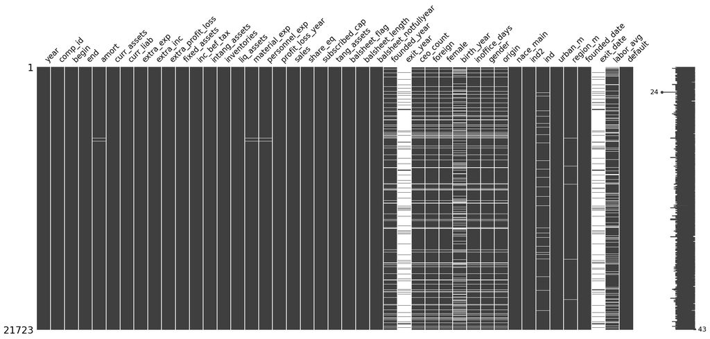

```python
graph_name("NA's view")
msno.matrix(df_2);
```

*Graph 10 : NA’s proportion 1*

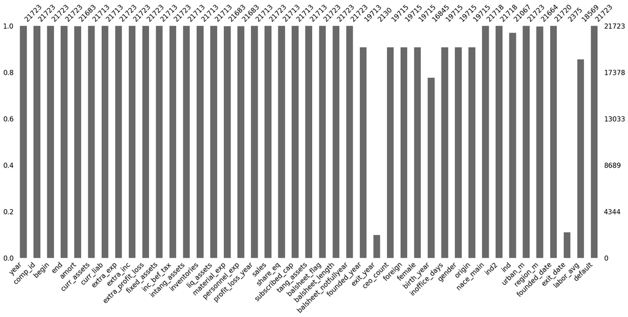

```python
graph_name("NA's proportion 1")
msno.bar(df_2);
```

Correlation beetween input and output variable :

*Graph 11 : Correlation*

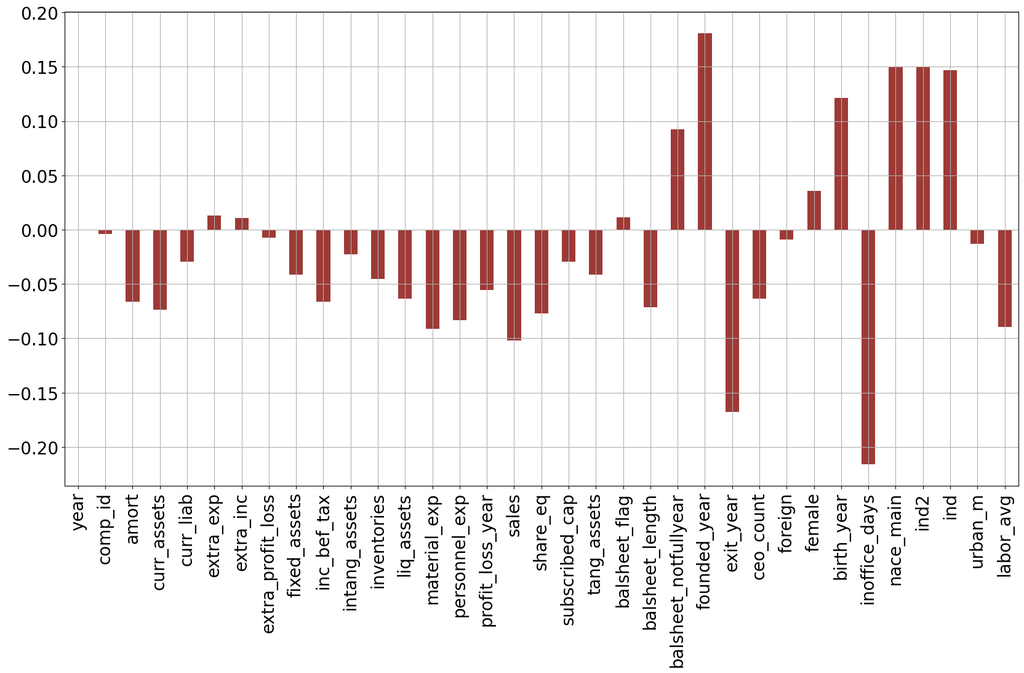

```python
graph_name("Correlation")
df_2.drop(['default'], axis = 1).corrwith(df_2['default']).plot.bar(figsize = (20, 10),
                                                                    fontsize = 20,rot = 90, grid = True,
                                                                   color = color_theme);
```

Correlation beetwen input variables :

```python
df_2.drop(['year','default'], axis = 1).corr(method='pearson').style.format("{:.2}").background_gradient(cmap=plt.get_cmap('coolwarm'), axis=1)
```

|  | comp_id | amort | curr_assets | curr_liab | extra_exp | extra_inc | extra_profit_loss | fixed_assets | inc_bef_tax | intang_assets | inventories | liq_assets | material_exp | personnel_exp | profit_loss_year | sales | share_eq | subscribed_cap | tang_assets | balsheet_flag | balsheet_length | balsheet_notfullyear | founded_year | exit_year | ceo_count | foreign | female | birth_year | inoffice_days | … |
| --- | --- | --- | --- | --- | --- | --- | --- | --- | --- | --- | --- | --- | --- | --- | --- | --- | --- | --- | --- | --- | --- | --- | --- | --- | --- | --- | --- | --- | --- | --- |
| comp_id | 1.0 | 0.00095 | 0.003 | 0.0028 | -0.0071 | -0.0059 | 0.0038 | 0.0014 | 0.00069 | 0.0085 | 0.0051 | 0.0014 | 0.00022 | -0.0024 | 0.00079 | -0.00062 | 0.0079 | 0.011 | -0.00086 | 0.0036 | -0.006 | 0.0068 | 4.6e-05 | 0.013 | -0.0016 | -0.007 | 0.0035 | 0.0095 | -0.002 | … |
| amort | 0.00095 | 1.0 | 0.48 | 0.4 | 0.037 | 0.06 | 0.093 | 0.75 | 0.12 | 0.4 | 0.35 | 0.32 | 0.52 | 0.54 | 0.07 | 0.59 | 0.49 | 0.3 | 0.77 | 0.073 | 0.02 | -0.026 | -0.11 | -0.039 | 0.099 | 0.17 | -0.065 | -0.084 | 0.018 | … |
| curr_assets | 0.003 | 0.48 | 1.0 | 0.67 | 0.015 | 0.048 | 0.13 | 0.29 | 0.22 | 0.31 | 0.74 | 0.61 | 0.75 | 0.6 | 0.11 | 0.74 | 0.57 | 0.28 | 0.26 | 0.13 | 0.011 | -0.019 | -0.15 | -0.074 | 0.13 | 0.21 | -0.092 | -0.093 | 0.022 | … |
| curr_liab | 0.0028 | 0.4 | 0.67 | 1.0 | 0.21 | 0.22 | 0.07 | 0.32 | -0.19 | 0.21 | 0.53 | 0.24 | 0.52 | 0.39 | -0.28 | 0.46 | 0.2 | 0.16 | 0.29 | 0.075 | 0.012 | -0.016 | -0.091 | -0.021 | 0.095 | 0.18 | -0.07 | -0.07 | -0.0079 | … |
| extra_exp | -0.0071 | 0.037 | 0.015 | 0.21 | 1.0 | 0.97 | 0.0076 | 0.11 | 0.0045 | 0.0054 | 0.0035 | 0.0073 | 0.013 | 0.0094 | 0.0035 | 0.014 | 0.036 | 0.026 | 0.0087 | 0.00023 | 0.0018 | -0.0022 | -0.044 | -0.014 | 0.013 | 0.039 | -0.024 | -0.025 | -0.00018 | … |
| extra_inc | -0.0059 | 0.06 | 0.048 | 0.22 | 0.97 | 1.0 | 0.26 | 0.13 | 0.06 | 0.036 | 0.014 | 0.023 | 0.027 | 0.024 | 0.061 | 0.03 | 0.065 | 0.048 | 0.024 | 1.3e-05 | 0.0032 | -0.003 | -0.029 | -0.076 | 0.025 | 0.034 | -0.016 | -0.012 | 0.0011 | … |
| extra_profit_loss | 0.0038 | 0.093 | 0.13 | 0.07 | 0.0076 | 0.26 | 1.0 | 0.082 | 0.22 | 0.12 | 0.041 | 0.063 | 0.058 | 0.06 | 0.22 | 0.062 | 0.12 | 0.09 | 0.062 | -0.00082 | 0.0054 | -0.0033 | -0.019 | -0.075 | 0.022 | 0.025 | -0.011 | -0.0073 | 0.0012 | … |
| fixed_assets | 0.0014 | 0.75 | 0.29 | 0.32 | 0.11 | 0.13 | 0.082 | 1.0 | 0.12 | 0.15 | 0.2 | 0.24 | 0.29 | 0.3 | 0.11 | 0.35 | 0.6 | 0.38 | 0.96 | 0.058 | 0.016 | -0.019 | -0.084 | -0.016 | 0.055 | 0.14 | -0.046 | -0.08 | 0.0096 | … |
| inc_bef_tax | 0.00069 | 0.12 | 0.22 | -0.19 | 0.0045 | 0.06 | 0.22 | 0.12 | 1.0 | 0.016 | -0.0083 | 0.33 | 0.16 | 0.15 | 0.94 | 0.3 | 0.39 | -0.02 | 0.11 | 0.013 | 0.016 | -0.019 | -0.078 | -0.029 | 0.02 | 0.014 | -0.027 | -0.053 | 0.053 | … |
| intang_assets | 0.0085 | 0.4 | 0.31 | 0.21 | 0.0054 | 0.036 | 0.12 | 0.15 | 0.016 | 1.0 | 0.28 | 0.12 | 0.26 | 0.28 | -0.00042 | 0.27 | 0.24 | 0.15 | 0.096 | 0.021 | -0.00079 | -0.0051 | -0.046 | -0.057 | 0.048 | 0.036 | -0.032 | -0.03 | -0.0072 | … |
| inventories | 0.0051 | 0.35 | 0.74 | 0.53 | 0.0035 | 0.014 | 0.041 | 0.2 | -0.0083 | 0.28 | 1.0 | 0.23 | 0.58 | 0.43 | -0.079 | 0.52 | 0.38 | 0.16 | 0.18 | 0.079 | 0.0067 | -0.013 | -0.097 | -0.062 | 0.064 | 0.13 | -0.055 | -0.053 | 0.0095 | … |
| liq_assets | 0.0014 | 0.32 | 0.61 | 0.24 | 0.0073 | 0.023 | 0.063 | 0.24 | 0.33 | 0.12 | 0.23 | 1.0 | 0.43 | 0.41 | 0.23 | 0.5 | 0.47 | 0.17 | 0.23 | 0.11 | 0.0045 | -0.011 | -0.12 | -0.04 | 0.069 | 0.13 | -0.061 | -0.084 | 0.039 | … |
| material_exp | 0.00022 | 0.52 | 0.75 | 0.52 | 0.013 | 0.027 | 0.058 | 0.29 | 0.16 | 0.26 | 0.58 | 0.43 | 1.0 | 0.67 | 0.048 | 0.96 | 0.45 | 0.21 | 0.27 | 0.14 | 0.026 | -0.034 | -0.14 | -0.0011 | 0.14 | 0.21 | -0.099 | -0.07 | 0.016 | … |
| personnel_exp | -0.0024 | 0.54 | 0.6 | 0.39 | 0.0094 | 0.024 | 0.06 | 0.3 | 0.15 | 0.28 | 0.43 | 0.41 | 0.67 | 1.0 | 0.062 | 0.81 | 0.45 | 0.21 | 0.29 | 0.14 | 0.019 | -0.025 | -0.15 | -0.037 | 0.13 | 0.21 | -0.085 | -0.1 | 0.014 | … |
| profit_loss_year | 0.00079 | 0.07 | 0.11 | -0.28 | 0.0035 | 0.061 | 0.22 | 0.11 | 0.94 | -0.00042 | -0.079 | 0.23 | 0.048 | 0.062 | 1.0 | 0.18 | 0.35 | -0.036 | 0.096 | -0.0038 | 0.012 | -0.015 | -0.052 | -0.026 | 0.0033 | -0.011 | -0.011 | -0.037 | 0.045 | … |
| sales | -0.00062 | 0.59 | 0.74 | 0.46 | 0.014 | 0.03 | 0.062 | 0.35 | 0.3 | 0.27 | 0.52 | 0.5 | 0.96 | 0.81 | 0.18 | 1.0 | 0.52 | 0.22 | 0.33 | 0.15 | 0.027 | -0.035 | -0.16 | -0.026 | 0.15 | 0.23 | -0.1 | -0.089 | 0.025 | … |
| share_eq | 0.0079 | 0.49 | 0.57 | 0.2 | 0.036 | 0.065 | 0.12 | 0.6 | 0.39 | 0.24 | 0.38 | 0.47 | 0.45 | 0.45 | 0.35 | 0.52 | 1.0 | 0.56 | 0.48 | 0.1 | 0.014 | -0.018 | -0.17 | -0.069 | 0.1 | 0.16 | -0.068 | -0.11 | 0.042 | … |
| subscribed_cap | 0.011 | 0.3 | 0.28 | 0.16 | 0.026 | 0.048 | 0.09 | 0.38 | -0.02 | 0.15 | 0.16 | 0.17 | 0.21 | 0.21 | -0.036 | 0.22 | 0.56 | 1.0 | 0.28 | 0.051 | 0.0097 | -0.0095 | -0.074 | -0.031 | 0.055 | 0.16 | -0.043 | -0.039 | -0.013 | … |
| tang_assets | -0.00086 | 0.77 | 0.26 | 0.29 | 0.0087 | 0.024 | 0.062 | 0.96 | 0.11 | 0.096 | 0.18 | 0.23 | 0.27 | 0.29 | 0.096 | 0.33 | 0.48 | 0.28 | 1.0 | 0.034 | 0.018 | -0.022 | -0.077 | -0.012 | 0.051 | 0.13 | -0.042 | -0.078 | 0.012 | … |
| balsheet_flag | 0.0036 | 0.073 | 0.13 | 0.075 | 0.00023 | 1.3e-05 | -0.00082 | 0.058 | 0.013 | 0.021 | 0.079 | 0.11 | 0.14 | 0.14 | -0.0038 | 0.15 | 0.1 | 0.051 | 0.034 | 1.0 | -0.17 | 0.17 | -0.026 | -0.068 | 0.044 | 0.12 | -0.027 | 0.0093 | -0.012 | … |
| balsheet_length | -0.006 | 0.02 | 0.011 | 0.012 | 0.0018 | 0.0032 | 0.0054 | 0.016 | 0.016 | -0.00079 | 0.0067 | 0.0045 | 0.026 | 0.019 | 0.012 | 0.027 | 0.014 | 0.0097 | 0.018 | -0.17 | 1.0 | -0.83 | -0.18 | 0.1 | 0.077 | -0.027 | -0.028 | -0.091 | 0.15 | … |
| balsheet_notfullyear | 0.0068 | -0.026 | -0.019 | -0.016 | -0.0022 | -0.003 | -0.0033 | -0.019 | -0.019 | -0.0051 | -0.013 | -0.011 | -0.034 | -0.025 | -0.015 | -0.035 | -0.018 | -0.0095 | -0.022 | 0.17 | -0.83 | 1.0 | 0.23 | -0.14 | -0.094 | 0.031 | 0.037 | 0.12 | -0.19 | … |
| founded_year | 4.6e-05 | -0.11 | -0.15 | -0.091 | -0.044 | -0.029 | -0.019 | -0.084 | -0.078 | -0.046 | -0.097 | -0.12 | -0.14 | -0.15 | -0.052 | -0.16 | -0.17 | -0.074 | -0.077 | -0.026 | -0.18 | 0.23 | 1.0 | 0.18 | -0.077 | -0.028 | 0.063 | 0.43 | -0.58 | … |
| exit_year | 0.013 | -0.039 | -0.074 | -0.021 | -0.014 | -0.076 | -0.075 | -0.016 | -0.029 | -0.057 | -0.062 | -0.04 | -0.0011 | -0.037 | -0.026 | -0.026 | -0.069 | -0.031 | -0.012 | -0.068 | 0.1 | -0.14 | 0.18 | 1.0 | 0.0094 | -0.021 | 0.0073 | 0.065 | -0.092 | … |
| ceo_count | -0.0016 | 0.099 | 0.13 | 0.095 | 0.013 | 0.025 | 0.022 | 0.055 | 0.02 | 0.048 | 0.064 | 0.069 | 0.14 | 0.13 | 0.0033 | 0.15 | 0.1 | 0.055 | 0.051 | 0.044 | 0.077 | -0.094 | -0.077 | 0.0094 | 1.0 | 0.084 | 0.012 | -0.0025 | -0.017 | … |
| foreign | -0.007 | 0.17 | 0.21 | 0.18 | 0.039 | 0.034 | 0.025 | 0.14 | 0.014 | 0.036 | 0.13 | 0.13 | 0.21 | 0.21 | -0.011 | 0.23 | 0.16 | 0.16 | 0.13 | 0.12 | -0.027 | 0.031 | -0.028 | -0.021 | 0.084 | 1.0 | -0.19 | -0.074 | -0.098 | … |
| female | 0.0035 | -0.065 | -0.092 | -0.07 | -0.024 | -0.016 | -0.011 | -0.046 | -0.027 | -0.032 | -0.055 | -0.061 | -0.099 | -0.085 | -0.011 | -0.1 | -0.068 | -0.043 | -0.042 | -0.027 | -0.028 | 0.037 | 0.063 | 0.0073 | 0.012 | -0.19 | 1.0 | 0.0099 | -0.064 | … |
| birth_year | 0.0095 | -0.084 | -0.093 | -0.07 | -0.025 | -0.012 | -0.0073 | -0.08 | -0.053 | -0.03 | -0.053 | -0.084 | -0.07 | -0.1 | -0.037 | -0.089 | -0.11 | -0.039 | -0.078 | 0.0093 | -0.091 | 0.12 | 0.43 | 0.065 | -0.0025 | -0.074 | 0.0099 | 1.0 | -0.34 | … |
| inoffice_days | -0.002 | 0.018 | 0.022 | -0.0079 | -0.00018 | 0.0011 | 0.0012 | 0.0096 | 0.053 | -0.0072 | 0.0095 | 0.039 | 0.016 | 0.014 | 0.045 | 0.025 | 0.042 | -0.013 | 0.012 | -0.012 | 0.15 | -0.19 | -0.58 | -0.092 | -0.017 | -0.098 | -0.064 | -0.34 | 1.0 | … |
| nace_main | -0.0069 | -0.11 | -0.21 | -0.1 | 0.0025 | -0.00065 | -0.012 | -0.026 | -0.099 | -0.069 | -0.14 | -0.14 | -0.19 | -0.18 | -0.058 | -0.21 | -0.12 | -0.023 | -0.024 | -0.048 | -0.05 | 0.067 | 0.24 | 0.068 | -0.031 | -0.039 | 0.19 | 0.2 | -0.21 | … |
| ind2 | -0.0068 | -0.11 | -0.21 | -0.1 | 0.0025 | -0.00059 | -0.012 | -0.026 | -0.1 | -0.069 | -0.14 | -0.14 | -0.19 | -0.18 | -0.058 | -0.21 | -0.12 | -0.022 | -0.023 | -0.048 | -0.05 | 0.067 | 0.24 | 0.069 | -0.031 | -0.04 | 0.19 | 0.2 | -0.21 | … |
| ind | -0.0071 | -0.12 | -0.23 | -0.13 | 0.0025 | -0.00061 | -0.012 | -0.03 | -0.093 | -0.071 | -0.17 | -0.14 | -0.2 | -0.19 | -0.051 | -0.22 | -0.12 | -0.02 | -0.027 | -0.046 | -0.048 | 0.065 | 0.23 | 0.075 | -0.03 | -0.046 | 0.19 | 0.2 | -0.2 | … |
| urban_m | -0.0059 | -0.0092 | -0.018 | -0.026 | -0.0086 | -0.0096 | -0.0048 | -0.0053 | 0.0099 | -0.022 | -0.0077 | -0.013 | -0.032 | -0.01 | 0.013 | -0.024 | 0.0054 | -0.0019 | -0.00081 | -0.016 | -0.002 | 0.0064 | 0.033 | -0.037 | -0.049 | -0.026 | 0.058 | 0.035 | 0.023 | … |
| labor_avg | -0.0096 | 0.5 | 0.5 | 0.34 | 0.0095 | 0.029 | 0.089 | 0.32 | 0.14 | 0.21 | 0.36 | 0.37 | 0.63 | 0.87 | 0.08 | 0.74 | 0.43 | 0.24 | 0.31 | 0.12 | -0.00064 | -0.011 | -0.14 | -0.021 | 0.13 | 0.22 | -0.093 | -0.1 | 0.019 | … |

*Graph 12 : Barplot Quantitative Variables*

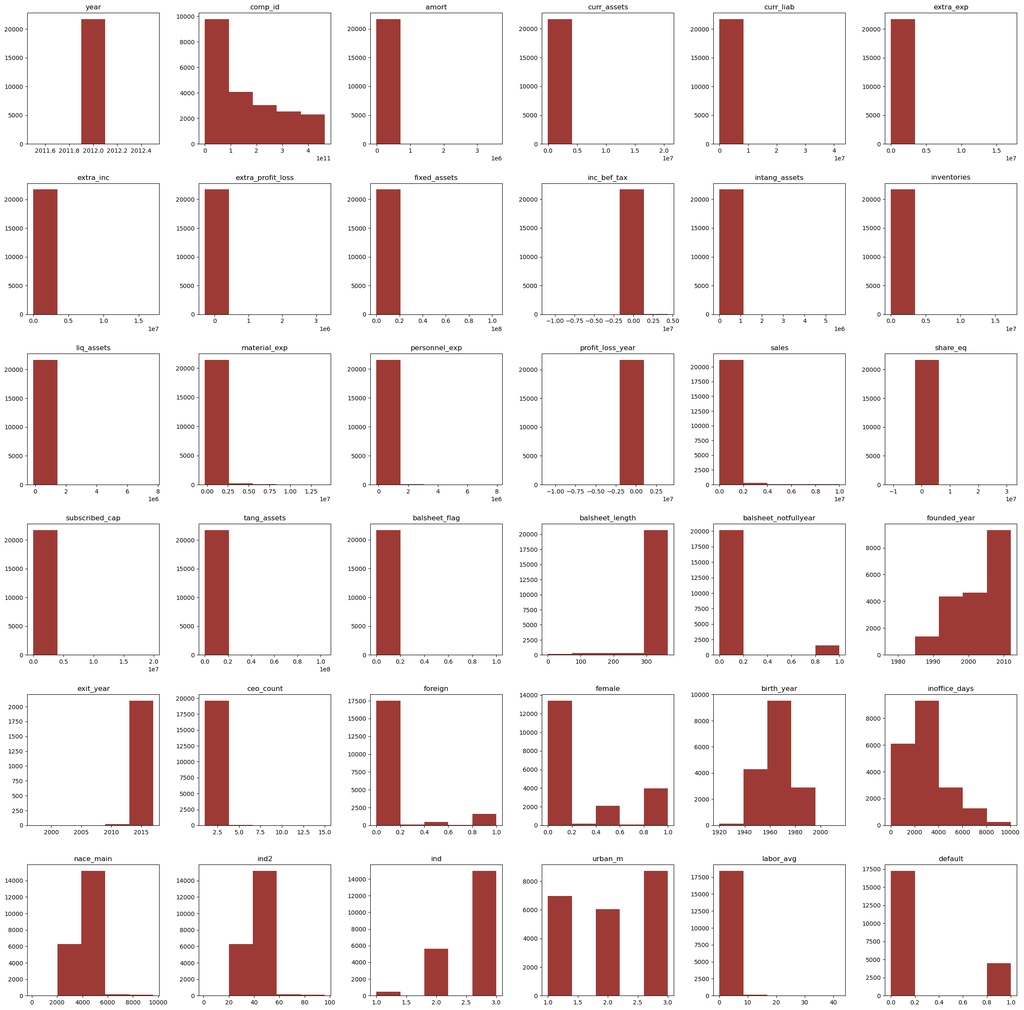

```python
graph_name("Barplot Quantitative Variables")
df_2.hist(color = color_theme, figsize = (30,30), grid = False, bins = 5);
```

## 2.2) Data cleaning

We will make 3 differents dataframe with different imputation or cleaning.

```python
df_21 = df_2.copy()
df_22 = df_2.copy()
df_23 = df_2.copy()
```

For our 2 first dataframe we drop the 4th variables because we don’t need them. We drop ‘female’ because we have ‘gender’ and we drop ‘founded_date’ because we have ‘founded_year’. And the last column we drop is ‘birth_year’ because it’s the column with the most NA. And for all our datframe we drop ‘exit_year’ and ‘exit_date’ because there is so many missing values.

```python
df_21 = df_21.drop(['year', 'comp_id', 'begin', 'end', 'exit_year','exit_date', 'female', 'birth_year', 'founded_date'], axis = 1)
df_22 = df_22.drop(['year', 'comp_id', 'begin', 'end', 'exit_year','exit_date', 'female', 'birth_year', 'founded_date'], axis = 1)
df_23 = df_23.drop(['exit_year', 'exit_date'], axis = 1)
```

### 2.2.1) first dataframe

#### 2.2.1.1) cleaning

We drop rows with NA if there is less than 100 NA for the variable.

```python
for column in df_21.columns.values:
    if (df_21[column].isna().sum() > 0 ) & (df_21[column].isna().sum() < 100):
        df_21 = df_21.dropna(subset=[column])
```

```python
df_21.isna().sum()
```

```
amort                      0
curr_assets                0
curr_liab                  0
extra_exp                  0
extra_inc                  0
extra_profit_loss          0
fixed_assets               0
inc_bef_tax                0
intang_assets              0
inventories                0
liq_assets                 0
material_exp               0
personnel_exp              0
profit_loss_year           0
sales                      0
share_eq                   0
subscribed_cap             0
tang_assets                0
balsheet_flag              0
balsheet_length            0
balsheet_notfullyear       0
founded_year            1989
ceo_count               1987
foreign                 1987
inoffice_days           1987
gender                  1987
origin                  1987
nace_main                  0
ind2                       0
ind                      649
urban_m                    0
region_m                   0
labor_avg               3130
default                    0
dtype: int64
```

```python
df_21.shape
```

```
(21610, 34)
```

We look the correlation of **ind** with others input variables.

```python
print(df_21.corrwith(df_21['ind']))
```

```
amort                  -0.117394
curr_assets            -0.223795
curr_liab              -0.122967
extra_exp               0.002472
extra_inc               0.000359
extra_profit_loss      -0.007845
fixed_assets           -0.027651
inc_bef_tax            -0.092485
intang_assets          -0.068352
inventories            -0.161719
liq_assets             -0.135781
material_exp           -0.202872
personnel_exp          -0.187134
profit_loss_year       -0.050224
sales                  -0.220055
share_eq               -0.121802
subscribed_cap         -0.019166
tang_assets            -0.025620
balsheet_flag          -0.045661
balsheet_length        -0.047909
balsheet_notfullyear    0.065159
founded_year            0.230713
ceo_count              -0.028645
foreign                -0.046350
inoffice_days          -0.196528
nace_main               0.953623
ind2                    0.953080
ind                     1.000000
urban_m                 0.020534
labor_avg              -0.157201
default                 0.147214
dtype: float64
```

**ind** has a big correlation with **ind2** and **nace_main** so we drop **ind**.

```python
df_21 = df_21.drop(['ind'], axis = 1)
```

```python
df_21.isna().sum()
```

```
amort                      0
curr_assets                0
curr_liab                  0
extra_exp                  0
extra_inc                  0
extra_profit_loss          0
fixed_assets               0
inc_bef_tax                0
intang_assets              0
inventories                0
liq_assets                 0
material_exp               0
personnel_exp              0
profit_loss_year           0
sales                      0
share_eq                   0
subscribed_cap             0
tang_assets                0
balsheet_flag              0
balsheet_length            0
balsheet_notfullyear       0
founded_year            1989
ceo_count               1987
foreign                 1987
inoffice_days           1987
gender                  1987
origin                  1987
nace_main                  0
ind2                       0
urban_m                    0
region_m                   0
labor_avg               3130
default                    0
dtype: int64
```

```python
len(df_21[df_21.isna().sum(axis=1) >= 5 ])
```

```
1987
```

```python
df_21 = df_21.dropna(subset=df_21.columns, thresh=len(df_21.columns) - 5)
```

```python
df_21.isna().sum()
```

```
amort                      0
curr_assets                0
curr_liab                  0
extra_exp                  0
extra_inc                  0
extra_profit_loss          0
fixed_assets               0
inc_bef_tax                0
intang_assets              0
inventories                0
liq_assets                 0
material_exp               0
personnel_exp              0
profit_loss_year           0
sales                      0
share_eq                   0
subscribed_cap             0
tang_assets                0
balsheet_flag              0
balsheet_length            0
balsheet_notfullyear       0
founded_year               2
ceo_count                  0
foreign                    0
inoffice_days              0
gender                     0
origin                     0
nace_main                  0
ind2                       0
urban_m                    0
region_m                   0
labor_avg               2705
default                    0
dtype: int64
```

We drop the two lines with NA in **founded_year**.

```python
df_21 = df_21.dropna(subset=['founded_year'])
```

We transform object columns in float column.

```python
object_column = []

for column in df_21.columns.values :
    if df_21[column].dtype == 'object':
        object_column.append(column)


label_endoders = {}

for column in object_column:
    LE = LabelEncoder()
    df_21[column] = LE.fit_transform(df_21[column]).astype(float)
    label_endoders[column] = LE
```

#### 2.2.1.2) **labor_avg**

We have to focus on NA of **labor_avg**. We will impute missing values with a regression.

```python
# dataframe 1 without NA
df_21_without_na = df_21.dropna(subset=['labor_avg'])
# dataframe 1 with NA
df_21_with_na = df_21[pd.isna(df_21['labor_avg'])]
```

```python
# define our input and output variables for the model
X = df_21_without_na.drop(['labor_avg'], axis = 1)
y = df_21_without_na['labor_avg']
```

```python
# take only column with a correlation with labor_avg > 0.3
column_cor_with_labor = []
for column in X.columns.values :
    if abs(y.corr(X[column])) > 0.3 :
        column_cor_with_labor.append(column)
```

```python
X = X[column_cor_with_labor]
```

```python
X_train, X_test, y_train, y_test = train_test_split(X, y, test_size = 0.3, random_state = 42)
```

##### linear regression

```python
# define the model
model_lr = LinearRegression()

# fit the model
model_lr.fit(X_train,y_train)

# prediction
y_pred = model_lr.predict(X_test)

# MSE :
mse_lr  = mean_squared_error(y_test,y_pred)

print('MSE Linear Regression =', mse_lr)
```

```
MSE Linear Regression = 0.6833296016478182
```

##### ridge regression

```python
# generate an array of alphas
alphas = 10**np.linspace(10,-2,100)*0.5


ridgecv = RidgeCV(alphas = alphas, scoring = 'neg_mean_squared_error')

#fit the model
ridgecv.fit(X_train, y_train)

ridge = Ridge(alpha = ridgecv.alpha_)

ridge.fit(X_train, y_train)
print('MSE Ridge : = ',mean_squared_error(y_test, ridge.predict(X_test)))
```

```
MSE Ridge : =  0.683303463414254
```

##### lasso regression

```python
lasso = Lasso(max_iter = 10000)
lassocv = LassoCV(alphas = None, cv = 10, max_iter = 100000)
lassocv.fit(X_train, y_train)
lasso.set_params(alpha=lassocv.alpha_)
lasso.fit(X_train, y_train)
print('MSE Lasso :', mean_squared_error(y_test, lasso.predict(X_test)))
```

```
MSE Lasso : 0.6626442785545502
```

#### 2.2.1.3) dataframe 1 final

We use lasso regression to predict our column **labor_avg**.

```python
X_final = df_21_with_na[column_cor_with_labor]
y_final = lasso.predict(X_final)
y_final
```

```
array([0.24282958, 0.23381048, 0.23442006, ..., 0.22247635, 0.22824688,
       0.26779084])
```

```python
df_21_with_na['labor_avg'] = y_final

# concat our 2 dataframe
df_21 = pd.concat([df_21_with_na, df_21_without_na], ignore_index=False)

# sort by index
df_21 = df_21.sort_index()

# replace negative values by 0
for column in df_21.columns.values:
    if df_21[column].dtype != 'object':
        df_21[column] = df_21[column].apply(lambda x: max(0, x))
```

### 2.2.2) Second dataframe

```python
# select our categorical and numerical columns
numeric_column = []
categorical_column = []

for colum in df_22.columns.values:
    if df_22[colum].dtype == 'object':
        categorical_column.append(colum)
    else :
        numeric_column.append(colum)

print(f'Nuerical columns : {numeric_column}')
print(f'Categorical columns : {categorical_column}')
```

```
Nuerical columns : ['amort', 'curr_assets', 'curr_liab', 'extra_exp', 'extra_inc', 'extra_profit_loss', 'fixed_assets', 'inc_bef_tax', 'intang_assets', 'inventories', 'liq_assets', 'material_exp', 'personnel_exp', 'profit_loss_year', 'sales', 'share_eq', 'subscribed_cap', 'tang_assets', 'balsheet_fl…
Categorical columns : ['gender', 'origin', 'region_m']
```

We will use IterativeImputer algorithm. The IterativeImputer algorithm in scikit-learn is a method for handling missing values based on regression. It’s an iterative approach that uses a regression model to impute missing values at each iteration, using other variables to predict the missing variable. The algorithm works in several steps:

Initially impute missing values with a simple strategy like mean, median, or mode. Then, fit a regression model to predict missing values from other variables. This regression can be linear, nonlinear, or any other type depending on the data. Impute missing values using the regression model. Steps 2 and 3 are repeated multiple times until convergence is achieved. Convergence is determined by a defined stopping criterion, such as the maximum number of iterations or the convergence of the mean differences between consecutive imputations.

The IterativeImputer algorithm is useful when dealing with Missing Not At Random (MNAR) data, where missing values are related to the value of the variable itself. It can be used for imputing continuous or categorical variables, although it may be slower than other imputation methods like simple imputation.

```python
# Impute missing values using iterative imputation
iterative_imputer = IterativeImputer(random_state=seed, max_iter=20, initial_strategy='median')
df_22[numeric_column] = iterative_imputer.fit_transform(df_22[numeric_column])

# Create an object to imput with the most frequent value
categorical_imputer = SimpleImputer(strategy='most_frequent')

# Apply imputation in our categorical columns
df_22[categorical_column] = categorical_imputer.fit_transform(df_22[categorical_column])
```

```python
# transform object columns in float columns

bject_column = []

for column in df_22.columns.values :
    if df_22[column].dtype == 'object':
        object_column.append(column)


label_endoders = {}

for column in object_column:
    LE = LabelEncoder()
    df_22[column] = LE.fit_transform(df_22[column]).astype(float)
    label_endoders[column] = LE
```

### 2.2.3) Third dataframe

For this dataframe we have more input variables than our others dataframe. We will impute missing values like our second dataframe with iterative imputation.

```python
# select our categorical and numerical columns
numeric_column = []
categorical_column = []

for colum in df_23.columns.values:
    if df_23[colum].dtype == 'object':
        categorical_column.append(colum)
    else :
        numeric_column.append(colum)

print(f'Nuerical columns : {numeric_column}')
print(f'Categorical columns : {categorical_column}')
```

```
Nuerical columns : ['year', 'comp_id', 'amort', 'curr_assets', 'curr_liab', 'extra_exp', 'extra_inc', 'extra_profit_loss', 'fixed_assets', 'inc_bef_tax', 'intang_assets', 'inventories', 'liq_assets', 'material_exp', 'personnel_exp', 'profit_loss_year', 'sales', 'share_eq', 'subscribed_cap', 'tang_as…
Categorical columns : ['begin', 'end', 'gender', 'origin', 'region_m', 'founded_date']
```

```python
# Impute missing values using iterative imputation
iterative_imputer = IterativeImputer(random_state=seed, max_iter=20, initial_strategy='median')
df_23[numeric_column] = iterative_imputer.fit_transform(df_23[numeric_column])

# Create an object to imput with the most frequent value
categorical_imputer = SimpleImputer(strategy='most_frequent')

# Apply imputation in our categorical columns
df_23[categorical_column] = categorical_imputer.fit_transform(df_23[categorical_column])
```

```python
object_column = []

for column in df_23.columns.values :
    if df_23[column].dtype == 'object':
        object_column.append(column)


label_endoders = {}

for column in object_column:
    LE = LabelEncoder()
    df_23[column] = LE.fit_transform(df_23[column]).astype(float)
    label_endoders[column] = LE
```

## 2.3) Classifier

In this part we will do functions of different classifier to find the auc score with our different dataframe.

### Logistic regression

```python
def LR(df, scale = False, gridsearch = False):

    X = df.drop(['default'], axis = 1)
    y = df['default']

    if scale:

        X_train, X_test, y_train, y_test = train_test_split(X, y, test_size = 0.3, random_state = seed)
        sc_X = StandardScaler()
        X_train = pd.DataFrame(sc_X.fit_transform(X_train))
        X_test = pd.DataFrame(sc_X.transform(X_test))

    else:

        X_train, X_test, y_train, y_test = train_test_split(X, y, test_size = 0.3, random_state = seed)

    if gridsearch:

        param_grid = {'max_iter' : [2000, 3000, 4000],
                      'solver' : ['lbfgs', 'liblinear'],
                      'random_state' : [seed]}

        # Create a base model
        clf = LogisticRegression()

        # Instantiate the grid search model
        grid_search = GridSearchCV(estimator = clf, param_grid = param_grid,
                                   cv = cv_fold, scoring = 'roc_auc')


        grid_result_lr = grid_search.fit(X_train, y_train)

        best_lr = grid_result_lr.best_estimator_
        # Make predictions on the test data
        y_pred = best_lr.predict_proba(X_test)[:,1]

        auc = roc_auc_score(y_test, y_pred)

        print(f'auc logistic regression with best parameters : {auc} with {grid_result_lr.best_params_}')

    else :

        logistic_regression = LogisticRegression(max_iter = 10000)

        # Fit the model on the training data
        logistic_regression.fit(X_train, y_train)

        # Make predictions on the test data
        y_pred = logistic_regression.predict_proba(X_test)[:,1]

        auc = roc_auc_score(y_test, y_pred)

        print(f'auc regression logistic : {auc}')
```

### Random forest

```python
def RF(df, scale=False, gridsearch = False):

    X = df.drop(['default'], axis = 1)
    y = df['default']

    if scale:

        X_train, X_test, y_train, y_test = train_test_split(X, y, test_size = 0.3, random_state = seed)
        sc_X = StandardScaler()
        X_train = pd.DataFrame(sc_X.fit_transform(X_train))
        X_test = pd.DataFrame(sc_X.transform(X_test))

    else:

        X_train, X_test, y_train, y_test = train_test_split(X, y, test_size = 0.3, random_state = seed)

    if gridsearch :

        param_grid = {
        'n_estimators': [50, 100],
        'max_depth': [None, 10, 20],
        'min_samples_split': [2, 5],
        'min_samples_leaf': [1, 2],
        'max_features': ['sqrt', 'log2'],
        'random_state': [seed]
        }

        # Create a base model
        clf = RandomForestClassifier(random_state=seed) #Initialize with whatever parameters you want to

        # Instantiate the grid search model
        grid_search = GridSearchCV(estimator = clf, param_grid = param_grid,
                                   cv = cv_fold, scoring = 'roc_auc')


        grid_result_rf = grid_search.fit(X_train, y_train)

        best_rf = grid_result_rf.best_estimator_
        # Make predictions on the test data
        y_pred = best_rf.predict_proba(X_test)[:,1]

        auc = roc_auc_score(y_test, y_pred)

        print(f'roc random forest with best parameters : {auc} with {grid_result_rf.best_params_}')

    else:
        # Create a Random Forest Regressor
        rf_classifer = RandomForestClassifier(random_state=seed)  # You can adjust the number of trees (n_estimators) as needed

        # Fit the model on the training data
        rf_classifer.fit(X_train, y_train)

        # Make predictions on the test data
        y_pred = rf_classifer.predict_proba(X_test)[:,1]

        auc = roc_auc_score(y_test, y_pred)

        print(f'auc random forest : {auc}')
```

### Neural Networks

```python
def NN(df, scale=False, gridsearch = False):

    X = df.drop(['default'], axis = 1)
    y = df['default']

    model = keras.Sequential([
    keras.layers.Dense(128, activation='relu', input_shape=(df.shape[1]-1,)),
    keras.layers.Dense(64, activation='relu'),
    keras.layers.Dense(2, activation='softmax')
    ])

    model.compile(optimizer='adam', loss='sparse_categorical_crossentropy', metrics=['accuracy'])

    if scale:

        X_train, X_temp, y_train, y_temp = train_test_split(X, y, test_size = 0.3, random_state = seed)
        X_val, X_test, y_val, y_test = train_test_split(X_temp, y_temp, test_size = 0.5, random_state = seed)


        sc_X = StandardScaler()
        X_train = pd.DataFrame(sc_X.fit_transform(X_train))
        X_test = pd.DataFrame(sc_X.transform(X_test))
        X_val = pd.DataFrame(sc_X.transform(X_val))

    else:

        X_train, X_temp, y_train, y_temp = train_test_split(X, y, test_size = 0.3, random_state = seed)
        X_val, X_test, y_val, y_test = train_test_split(X_temp, y_temp, test_size = 0.5, random_state = seed)

    if gridsearch :

        param_grid = {
            'optimizer': ['adam', 'sgd'],  # You can add other optimizers
            'neurons_layer1': [64, 128],
            'neurons_layer2': [32, 64],
            'batch_size': [5, 10],
            'epochs': [10, 20],
            'validation_data'  : [(X_val, y_val)]
        }


        clf = keras.Sequential([
                                keras.layers.Dense(128, activation='relu', input_shape=(df.shape[1]-1,)),
                                keras.layers.Dense(64, activation='relu'),
                                keras.layers.Dense(2, activation='softmax')
                                ])

        # Instantiate the grid search model
        grid_search = GridSearchCV(estimator = clf, param_grid = param_grid,
                                   cv = cv_fold, scoring = 'roc_auc')


        grid_result_rf = grid_search.fit(X_train, y_train)

        best_rf = grid_result_rf.best_estimator_
        # Make predictions on the test data

        y_probs = best_rf.predict(X_test)

        # Extrait les probabilités pour la classe positive (class 1)
        y_pred = y_probs[:, 1]

        # Calculez le ROC AUC
        auc = roc_auc_score(y_test, y_pred)

        print(f'auc neural network with best parameters : {auc} with {grid_result_rf.best_params_}')


    else:

        model.fit(X_train, y_train, epochs=20, batch_size=5, validation_data=(X_val, y_val))

        y_probs = model.predict(X_test)

        # Extrait les probabilités pour la classe positive (class 1)
        y_pred = y_probs[:, 1]

        # Calculez le ROC AUC
        auc = roc_auc_score(y_test, y_pred)

        print(f'auc neural network : {auc}')
```

### Apply classifier on our dataframe

#### Dataframe 1

##### Logistic Regression

```python
LR(df_21)
```

```
auc regression logistic : 0.7403623677116006
```

```python
LR(df_21, True)
```

```
auc regression logistic : 0.7391690002259819
```

```python
LR(df_21, scale = False, gridsearch = True)
```

```
auc logistic regression with best parameters : 0.7404052020245999 with {'max_iter': 2000, 'random_state': 42, 'solver': 'liblinear'}
```

```python
LR(df_21, scale = True, gridsearch=True)
```

```
auc logistic regression with best parameters : 0.7391690002259819 with {'max_iter': 2000, 'random_state': 42, 'solver': 'lbfgs'}
```

##### Random Forest

```python
RF(df_21)
```

```
auc random forest : 0.8195816973739922
```

```python
RF(df_21, scale = True)
```

```
auc random forest : 0.8195743820489326
```

```python
RF(df_21, scale = False, gridsearch = True)
```

```
roc random forest with best parameters : 0.8211556380356008 with {'max_depth': 10, 'max_features': 'sqrt', 'min_samples_leaf': 2, 'min_samples_split': 5, 'n_estimators': 100, 'random_state': 42}
```

```python
RF(df_21, scale = True, gridsearch = True)
```

```
roc random forest with best parameters : 0.8212896054342818 with {'max_depth': 10, 'max_features': 'sqrt', 'min_samples_leaf': 2, 'min_samples_split': 5, 'n_estimators': 100, 'random_state': 42}
```

##### Neural Networks

```python
NN(df_21)
```

```
auc neural network : 0.49918032786885247
```

```python
NN(df_21, scale = True)
```

```
auc neural network : 0.7834776714849622
```

```python
NN(df_21, scale = False, gridsearch = True)
```

[output not shown]

```python
NN(df_21, scale = True, gridsearch = True)
```

[output not shown]

#### Dataframe 2

##### Logistic Regression

```python
LR(df_22)
```

```
auc regression logistic : 0.7337923953327186
```

```python
LR(df_22, True)
```

```
auc regression logistic : 0.7337213665030331
```

```python
LR(df_22, scale = False, gridsearch = True)
```

```
auc logistic regression with best parameters : 0.733862994552547 with {'max_iter': 2000, 'random_state': 42, 'solver': 'liblinear'}
```

```python
LR(df_22, scale = True, gridsearch=True)
```

```
auc logistic regression with best parameters : 0.7337213665030331 with {'max_iter': 2000, 'random_state': 42, 'solver': 'lbfgs'}
```

##### Random Forest

```python
RF(df_22)
```

```
auc random forest : 0.8282791404365982
```

```python
RF(df_22, scale = True)
```

```
auc random forest : 0.8285891755500437
```

```python
RF(df_22, scale = False, gridsearch = True)
```

```
roc random forest with best parameters : 0.8318229921467318 with {'max_depth': None, 'max_features': 'sqrt', 'min_samples_leaf': 2, 'min_samples_split': 5, 'n_estimators': 100, 'random_state': 42}
```

```python
RF(df_22, scale = True, gridsearch = True)
```

```
roc random forest with best parameters : 0.8316275196618113 with {'max_depth': None, 'max_features': 'sqrt', 'min_samples_leaf': 2, 'min_samples_split': 5, 'n_estimators': 100, 'random_state': 42}
```

##### Neural Networks

```python
NN(df_22)
```

```
auc neural network : 0.5007342143906021
```

```python
NN(df_22, scale = True)
```

```
auc neural network : 0.8065809304757641
```

```python
NN(df_22, scale = False, gridsearch = True)
```

[output not shown]

```python
NN(df_22, scale = True, gridsearch = True)
```

[output not shown]

#### Dataframe 3

##### Logistic Regression

```python
LR(df_23)
```

```
auc regression logistic : 0.5044410202947697
```

```python
LR(df_23, True)
```

```
auc regression logistic : 0.739775428607434
```

```python
LR(df_23, scale = False, gridsearch = True)
```

```
auc logistic regression with best parameters : 0.5044410202947697 with {'max_iter': 2000, 'random_state': 42, 'solver': 'lbfgs'}
```

```python
LR(df_23, scale = True, gridsearch=True)
```

```
auc logistic regression with best parameters : 0.739775428607434 with {'max_iter': 2000, 'random_state': 42, 'solver': 'lbfgs'}
```

##### Random Forest

```python
RF(df_23)
```

```
auc random forest : 0.8321952490877951
```

```python
RF(df_23, scale = True)
```

```
auc random forest : 0.8318928037484892
```

```python
RF(df_23, scale = False, gridsearch = True)
```

```
roc random forest with best parameters : 0.8350875974498359 with {'max_depth': 20, 'max_features': 'log2', 'min_samples_leaf': 1, 'min_samples_split': 5, 'n_estimators': 100, 'random_state': 42}
```

```python
RF(df_23, scale = True, gridsearch = True)
```

```
roc random forest with best parameters : 0.8350704130555572 with {'max_depth': 20, 'max_features': 'log2', 'min_samples_leaf': 1, 'min_samples_split': 5, 'n_estimators': 100, 'random_state': 42}
```

##### Neural Networks

```python
NN(df_23)
```

```
auc neural network : 0.5011636927851048
```

```python
NN(df_23, scale = True)
```

```
auc neural network : 0.8053204056918988
```

```python
NN(df_23, scale = False, gridsearch = True)
```

[output not shown]

```python
NN(df_23, scale = True, gridsearch = True)
```

[output not shown]

### Comparative table

```python
arrays = [np.array(["Logistic Regression", "Logistic Regression","Logistic Regression","Logistic Regression",
                    "Random Forest", "Random Forest", "Random Forest", "Random Forest",
                    "Neural Networks", "Neural Networks", "Neural Networks", "Neural Networks"]),
          np.array(["No scale, no gridsearch", "Scale", "Gridsearch", "Scale + gridsearch",
                    "No scale, no gridsearch", "Scale", "Gridsearch", "Scale + gridsearch",
                    "No scale, no gridsearch", "Scale", "Gridsearch", "Scale + gridsearch",]),]

df_to_compare_model = pd.DataFrame(np.array([
                                             [0.74036,0.73379,0.50444],
                                             [0.73917,0.73372,0.73978],
                                             [0.74041,0.73386,0.50444],
                                             [0.73917,0.73372,0.73978],
                                             [0.81958,0.82828,0.83220],
                                             [0.81957,0.82859,0.83189],
                                             [0.82116,0.83182,0.83509],
                                             [0.82129,0.83163,0.83507],
                                             [0.49918,0.50073,0.50116],
                                             [0.78348,0.80658,0.80532],
                                             [0.81586,0.82846,0.83264],
                                             [0.81606,0.82842,0.83252],
                                             ]),
                                    index = arrays, columns=['Datframe 1', 'Dataframe 2', 'Dataframe 3'])

df_to_compare_model
```

|  |  | Datframe 1 | Dataframe 2 | Dataframe 3 |
| --- | --- | --- | --- | --- |
| Logistic Regression | No scale, no gridsearch | 0.74036 | 0.73379 | 0.50444 |
|  | Scale | 0.73917 | 0.73372 | 0.73978 |
|  | Gridsearch | 0.74041 | 0.73386 | 0.50444 |
|  | Scale + gridsearch | 0.73917 | 0.73372 | 0.73978 |
| Random Forest | No scale, no gridsearch | 0.81958 | 0.82828 | 0.83220 |
|  | Scale | 0.81957 | 0.82859 | 0.83189 |
|  | Gridsearch | 0.82116 | 0.83182 | 0.83509 |
|  | Scale + gridsearch | 0.82129 | 0.83163 | 0.83507 |
| Neural Networks | No scale, no gridsearch | 0.49918 | 0.50073 | 0.50116 |
|  | Scale | 0.78348 | 0.80658 | 0.80532 |
|  | Gridsearch | 0.81586 | 0.82846 | 0.83264 |
|  | Scale + gridsearch | 0.81606 | 0.82842 | 0.83252 |

```python
max_value = df_to_compare_model.values.max()  # Get the max value
max_indices = np.where(df_to_compare_model.values == max_value)

max_rows, max_columns = max_indices

print(f"The maximum value is {max_value} with:")
for row, column in zip(max_rows, max_columns):
    print(df_to_compare_model.index[row], df_to_compare_model.columns[column])
```

```
The maximum value is 0.83509 with:
('Random Forest', 'Gridsearch') Dataframe 3
```